# Visualizations in R

Sarah Wellberg

Most of the examples use a set of 100 pre- and post-test scores on a 50-item test.

Some examples are also from the data frame *data*, printed below.

| id | score | grade | color | teacher |
| --- | --- | --- | --- | --- |
| s100 | 85 | 10 | red | Mr. Stangl |
| s200 | 95 | 10 | orange | Ms. Wellberg |
| s300 | 90 | 9 | yellow | Ms. Wellberg |
| s400 | 80 | 9 | green | Mr. Stangl |
| s500 | 70 | 10 | blue | Mr. Stangl |
| s600 | 75 | 9 | purple | Ms. Wellberg |

## Basic Graphs

The following are the basic codes for the main types of graphics. Note that the default settings are very basic. R will use the the specified variable names for the axes labels and the main title, and the axes will be scaled based on the minimum and maximum data values.

### Histograms

*Basic Code*: `hist(vector)`.

*Example*:

We’ll make the most basic histogram of pre-test scores.

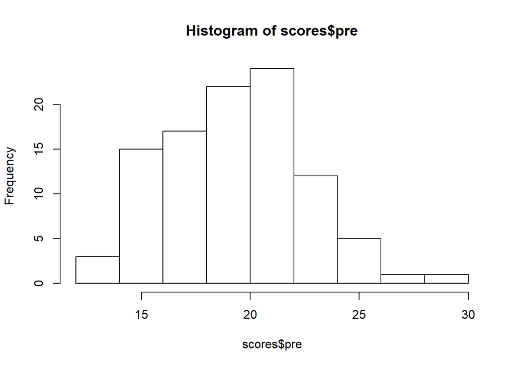

```r
hist(scores$pre)
```

#### Setting Bin Width

You can set the x-values for which histogram bins begin and end by using the `breaks` option. I’d recommend using the `seq` function to create the vector of evenly-spaced values.

*Code*:

```
hist(vector,
     breaks = seq(start, end, increment)
```

*Example*:

Let’s make a histogram of the pre-test scores with bins of width 2.5 using the `seq` command

The minimum score is 12, and the maximum is 29. I’ll make the bins go from 10 to 30.

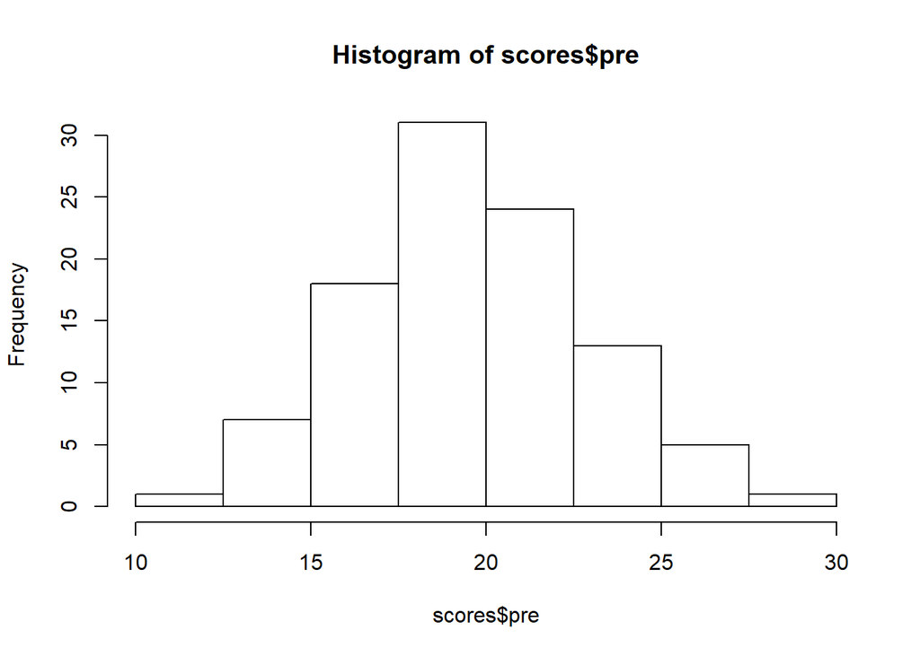

```r
hist(scores$pre,
     breaks = seq(10, 30, 2.5))
```

### Scatter Plots

*Basic Code*: `plot(x_vector, y_vector)`.

*Example*:

Let’s plot pre-test scores on the x-axis and post-test scores on the y-axis.

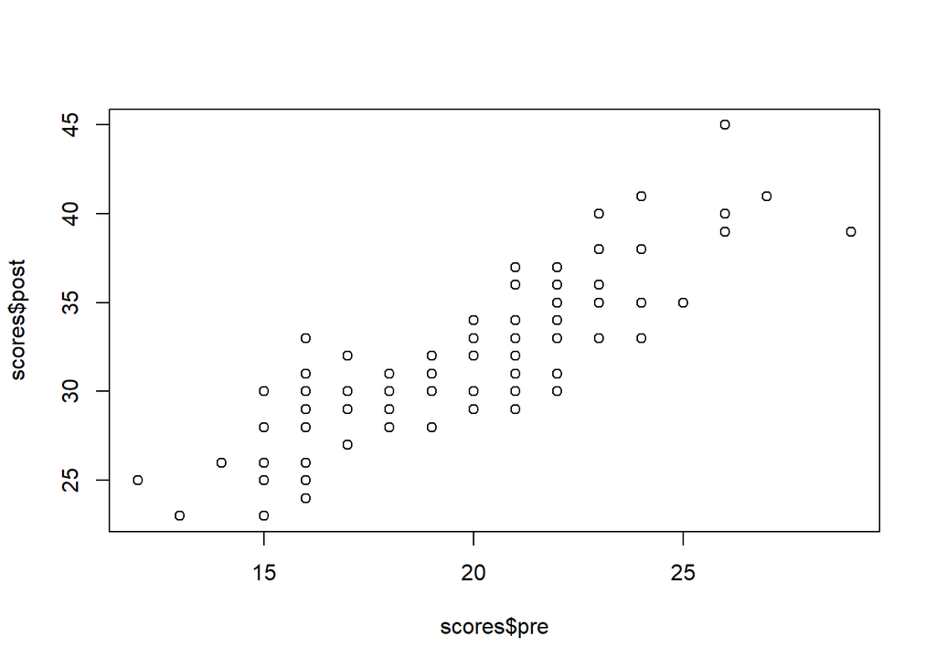

```r
plot(scores$pre,
     scores$post)
```

#### Shapes

The options 0-25 can be written as numbers, the rest (and any other symbol you want to use) need to be in quotation marks.

*Code*:

```
plot(x,
     y,
     pch = value)
```

*Number Example*:

Let’s make the pre- and post-test scores plot with filled-in, right-side-up triangles using option 17.

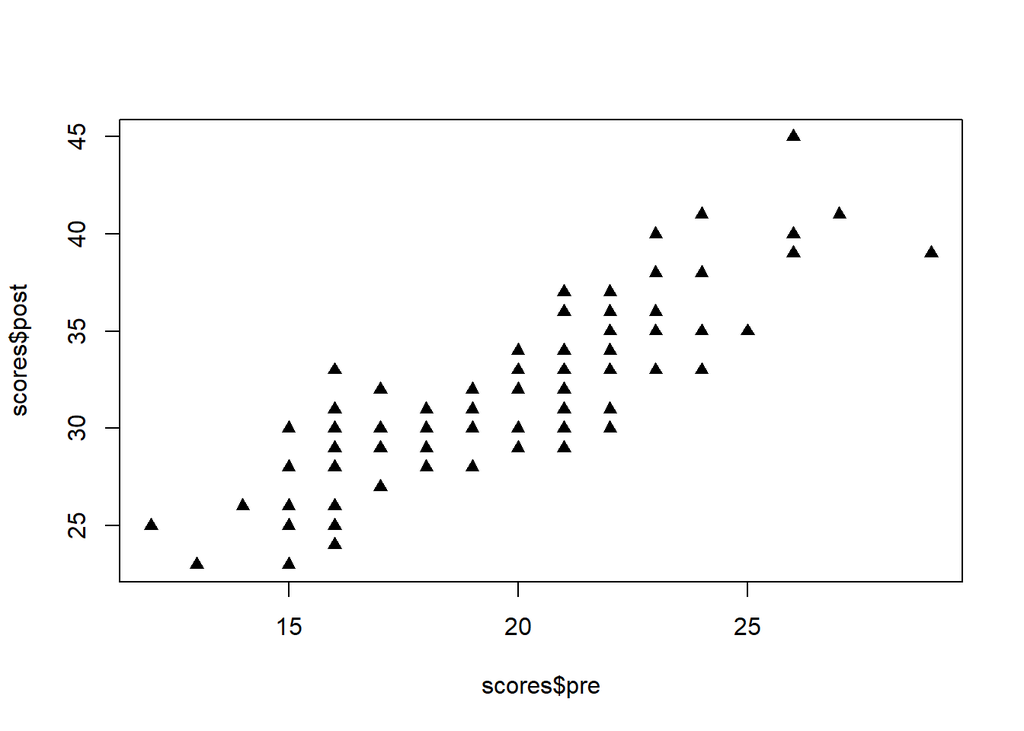

```r
plot(scores$pre,
     scores$post,
     pch = 17)
```

*Character Example*:

Let’s make the data points show up as “s”.

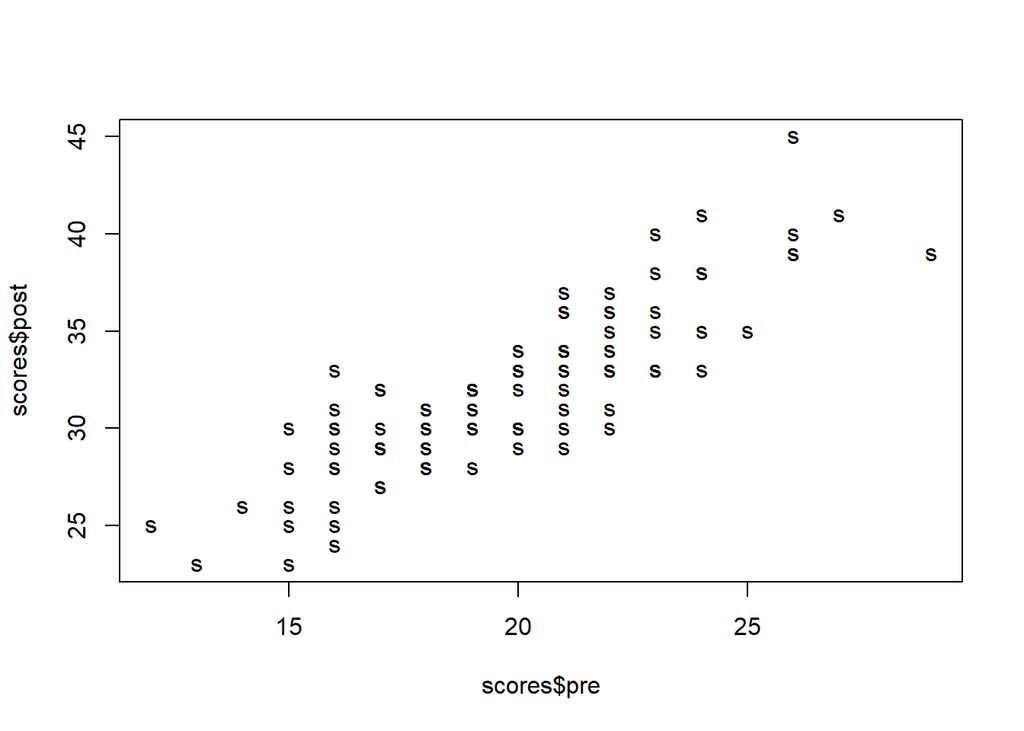

```r
plot(scores$pre,
     scores$post,
     pch = "s")
```

#### Multiple sets of points on one plot

Once you have used the `plot` function to make a scatter plot, you can add another set of points to the plot by using the `points` function.

*Notes*:

- The plot will keep the scale limits from the `plot` function, so the new poitns may get cut off if the window isn’t big enough.
- The new points will have the default shape and color. You’ll want to change the color or shape settings and add a legend, so you can tell which points represent which data sets. (See the General Options and Legend sections for details)

*Basic Code*:

```
plot(x1, y1)
points(x2, y2)
```

*Example*:

We have a second set of pre- and post-test scores. Let’s plot these two sets of scores on the same axes.

I’ll also set the axes limits to be the min and max values for the two data sets.

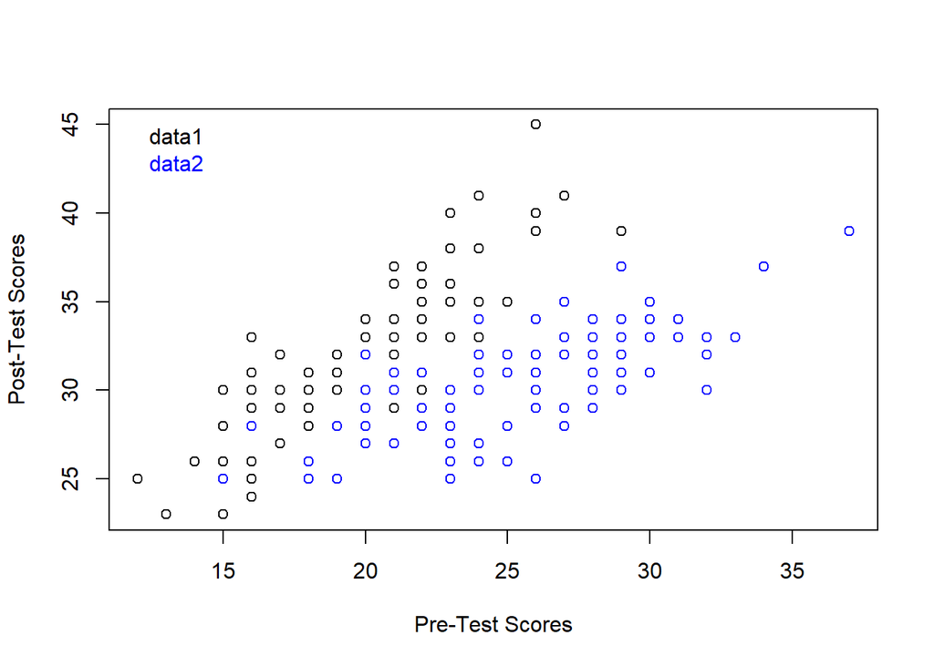

```r
# Min/Max
  xmin <- min(scores$pre, scores2$pre)
  xmax <- max(scores$pre, scores2$pre)

  ymin <- min(scores$post, scores2$post)
  ymax <- max(scores$post, scores2$post)

# Plots
  plot(scores$pre,
       scores$post,
       xlim = c(xmin, xmax),
       ylim = c(ymin, ymax),
       xlab = "Pre-Test Scores",
       ylab = "Post-Test Scores")
  points(scores2$pre,
         scores2$post,
         col = "blue")
  legend("topleft",
         legend = c("data1", "data2"),
         text.col = c("black", "blue"),
         bty = "n")
```

### Bar Graphs

You can either graph a vector of values or a whole matrix of values.

#### Graphing one vector

*Basic Code*: `barplot(vector)`

*Example*:

Let’s make a bargraph of the pre-test scores for the first 5 students in the data frame.

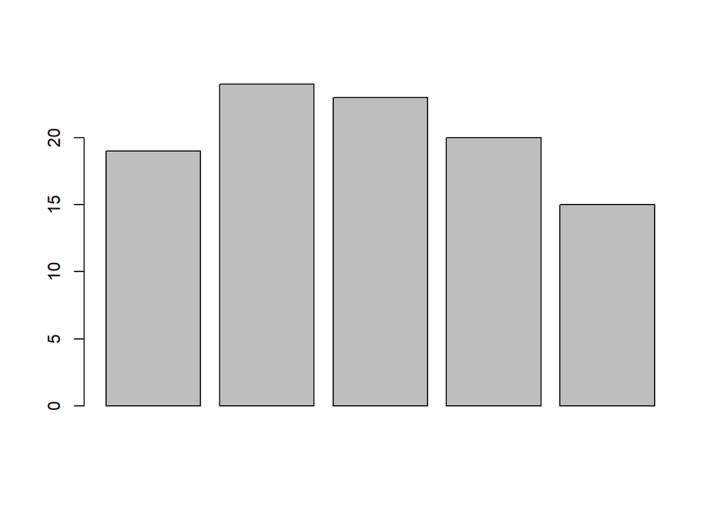

```r
barplot(scores$pre[1:5])
```

Note that the bars are unlabeled. To give them labels, use the option `names.arg = vector`

*Code*: `barplot(vector, names.arg = names_vector)`

*Example*:

We’ll add labels to the bars in the graph above.

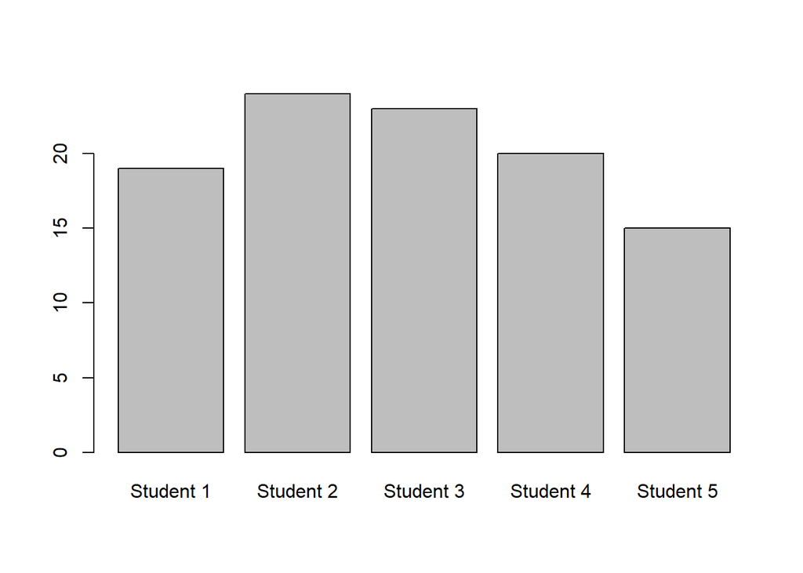

```r
barplot(scores$pre[1:5],
        names.arg = paste("Student", 1:5))
```

#### Graphing multiple values

If you want multiple values ploted, you need to make a matrix of values with the data that will be grouped together in columns.

You’ll want to add a legend, so that people can tell which values are which. See the legends tab for details.

Note that you can’t change the names once you’ve made a matrix. If you want to add column and row names to keep track of your data (which you should), make a data frame first, chagne the names, then turn it into a matrix.

*Matrix Example*:

Let’s plot both the pre- and post-test scores for the first 5 students. We’ll need to make a matrix where each column represents a student, the pre-test scores are in the first row, and the post-test scores are in the second row.

```
score_matrix <- data.frame(rbind(scores$pre[1:5],
                                 scores$post[1:5]))

names(score_matrix) <- paste("s", 1:5, sep = "")
row.names(score_matrix) <- c("pre", "post")

score_matrix %<>% as.matrix()
```

|  | s1 | s2 | s3 | s4 | s5 |
| --- | --- | --- | --- | --- | --- |
| **pre** | 19 | 24 | 23 | 20 | 15 |
| **post** | 30 | 41 | 33 | 33 | 26 |

1. Stacked bars

The default setting is for the bars to be stacked. The first row values will be on the bottom, and the last row will be on the top.

*Code*: `barplot(matrix)`

*Example*:

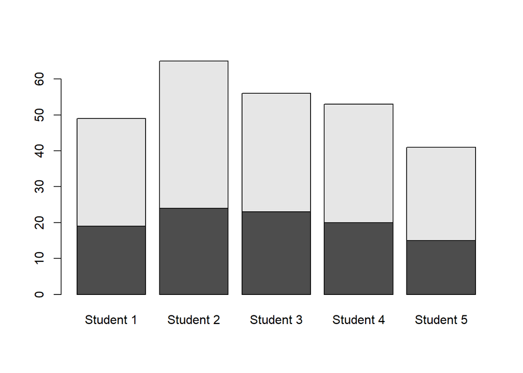

```r
barplot(score_matrix,
        names.arg = paste("Student", 1:5))
```

2. Side-by-side bars

If you want the bars to be next to each other, use the `beside = TRUE` option. The first row will be on the left, and the last row will be on the right for each group.

*Code*: `barplot(matrix, beside = TRUE)`

*Example*:

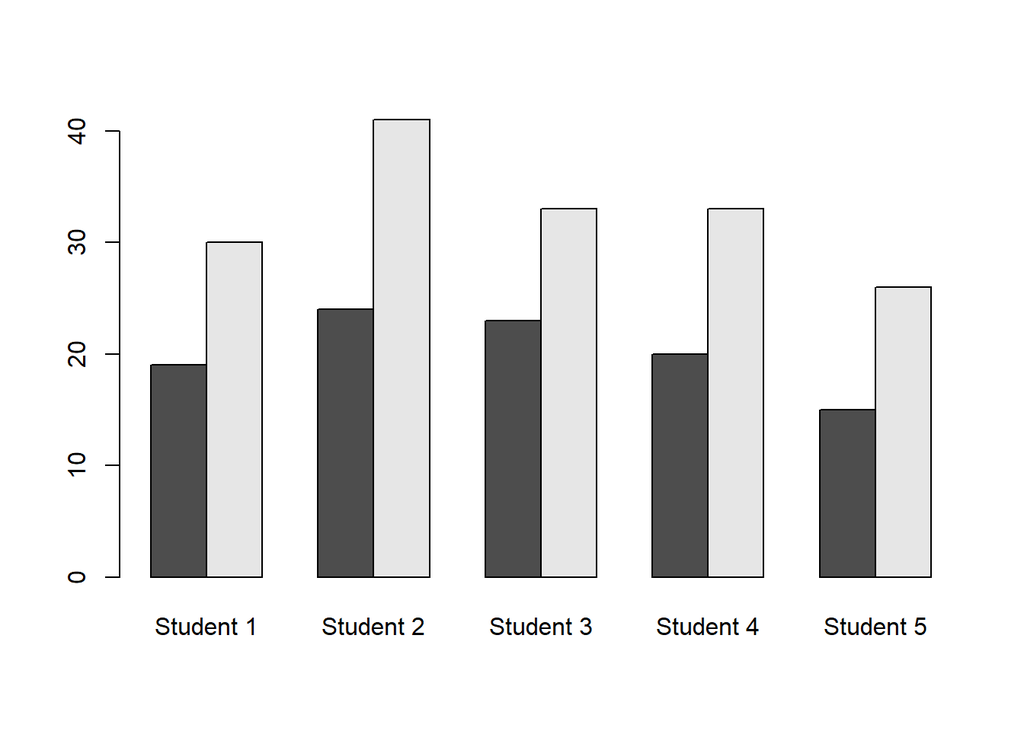

```r
barplot(score_matrix,
        beside = TRUE,
        names.arg = paste("Student", 1:5))
```

### Box Plots

*Basic Code*: `boxplot(vector1, vector2, ...)`

*Example*:

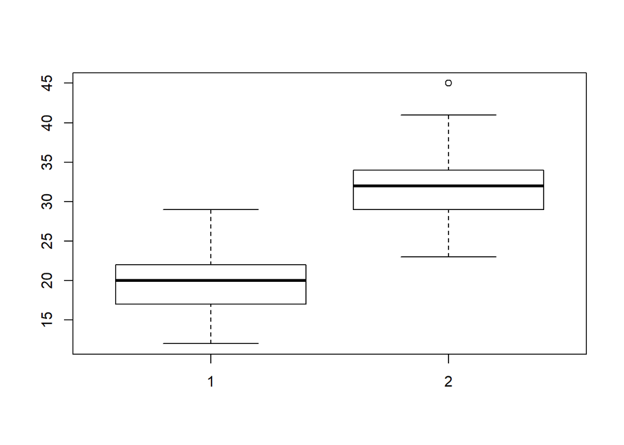

```r
boxplot(scores$pre,
        scores$post)
```

#### Naming the Boxes

If you just enter the vectors you want to plot, R will just name them 1, 2, 3, …

To use more meaningful labels, use the `names` option.

You can also add lables to the overall axes. See the Axes section in the General Options tab for details.

*Code*:

```
boxplot(vector1,
        vector2,
        ...,
        names = c("name1", "name2", ...))
```

*Example*:

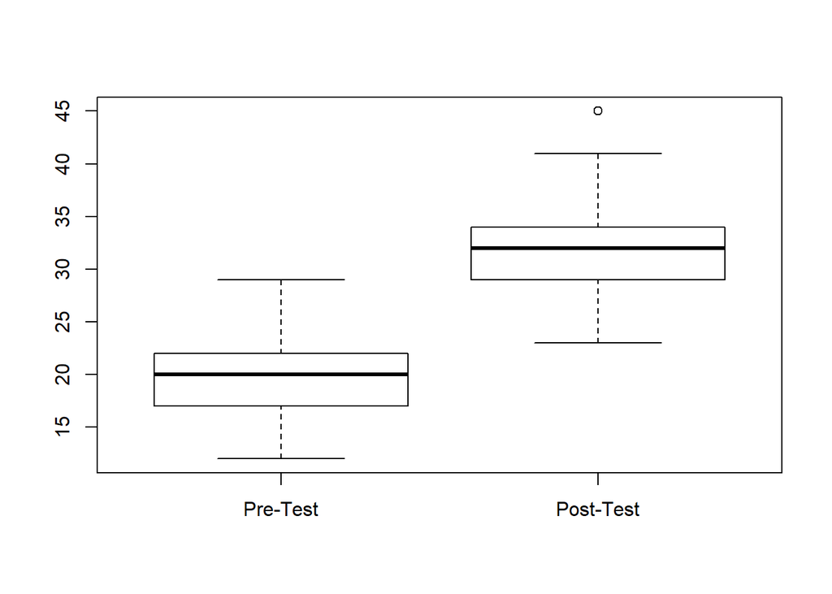

```r
boxplot(scores$pre,
        scores$post,
        names = c("Pre-Test", "Post-Test"))
```

#### Grouping the Data

You can make a st of boxplots for values grouped by a second variable. It’ll group the data in alphabetical/numeric order by the grouping variable and automatically name each box with the grouping values.

*Code*:

```
boxplot(data_vector ~ grouping_vector)
```

*Example*:

Let’s make boxplots for the scores in the *data* data frame grouped by teacher.

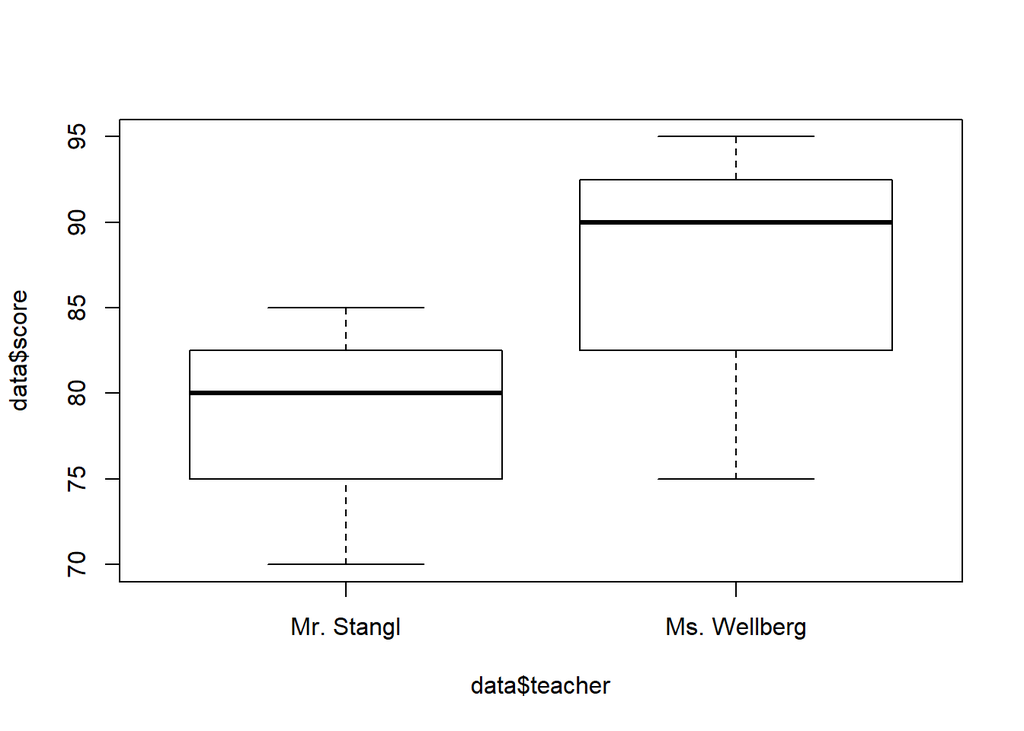

```r
boxplot(data$score ~ data$teacher)
```

## General Options

These options can be used with any type of graph.

### Axes

There are lots of fancy things you can do with axis labels, but we’ll just do the basics here.

#### Values

Chose the range of values for each axis by using the `xlim` and `ylim` options.

*Code*:

```
plot_type(data_vectors,
          xlim = c(xmin, xmax),
          ylim = c(ymin, ymax))
```

*Example*:

Let’s plot the “grade” and “score” values from the *data* data frame.

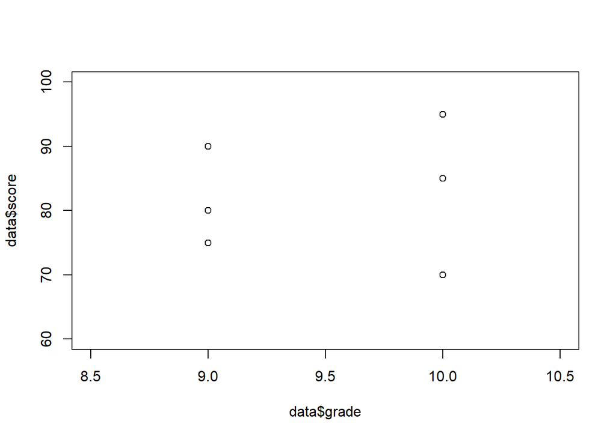

```r
plot(data$grade,
     data$score,
     xlim = c(8.5, 10.5),
     ylim = c(60, 100))
```

#### Labels

Label your x and y axes variable using the `xlab` and `ylab` options.

*Code*:

```
plot_type(data_vectors,
          xlab = "X Label",
          ylab = "Y Label")
```

*Example*:

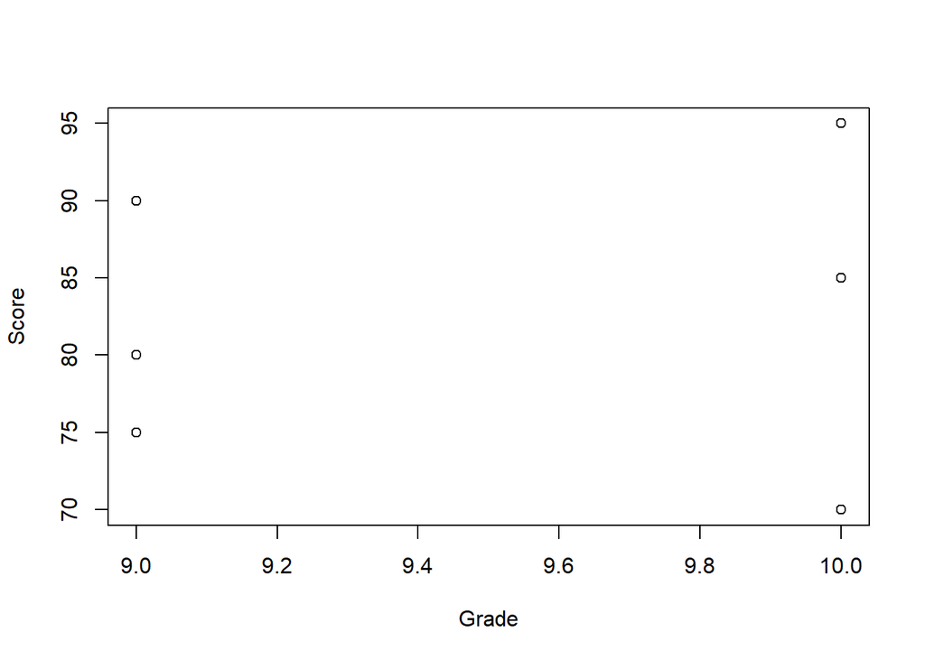

```r
plot(data$grade,
     data$score,
     xlab = "Grade",
     ylab = "Score")
```

### Title

You can give your graph a title using the `main` option.

*Note*: If you have multiple graphs in a window and want to have a main title for all of them, see the Window Options: Outer Text section.

*Code*:

```
plot_type(data_vectors,
          main = "Title")
```

*Example*:

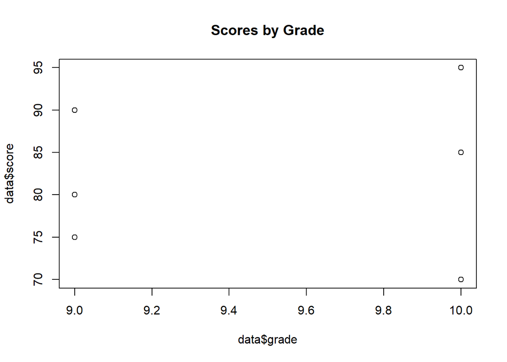

```r
plot(data$grade,
     data$score,
     main = "Scores by Grade")
```

### Size

The various `cex` options let you change the size of different parts of the graph. The number you enter will scale the size. 1 is the default. 2 would double the normal size, and 0.5 would cut the size in half.

#### Plotted Points

Use `cex` to change the size of plotted data points.

*Code*:

```
plot(x,
     y,
     cex = scale)
```

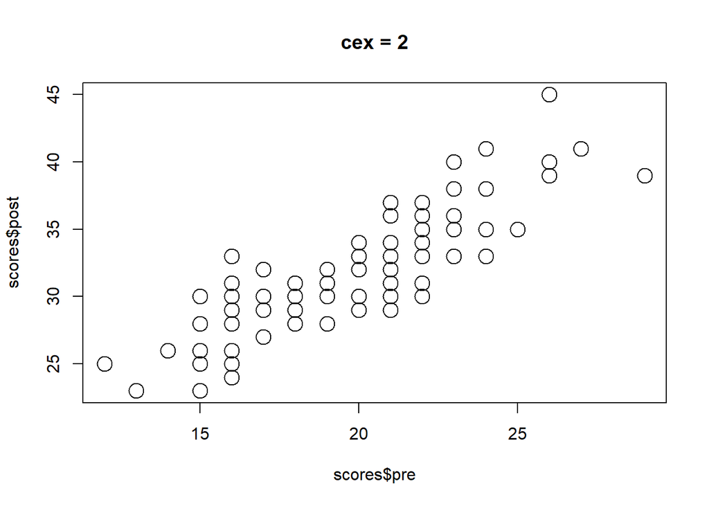

```r
plot(scores$pre,
     scores$post,
     main = "cex = 2",
     cex = 2)
```

#### Axes

Use `cex.axis` to change the size of the number labels on the axes.

*Code*:

```
plot(x,
     y,
     cex.axis = scale)
```

*Example*

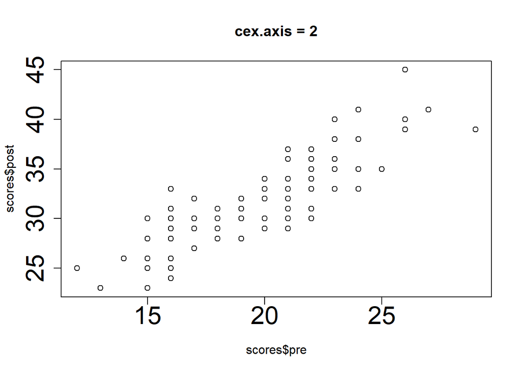

```r
plot(scores$pre,
     scores$post,
     main = "cex.axis = 2",
     cex.axis = 2)
```

#### Lables

Use `cex.lab` to change the size of the variable labels on the axes.

*Code*:

```
plot(x,
     y,
     cex.lab = scale)
```

*Example*

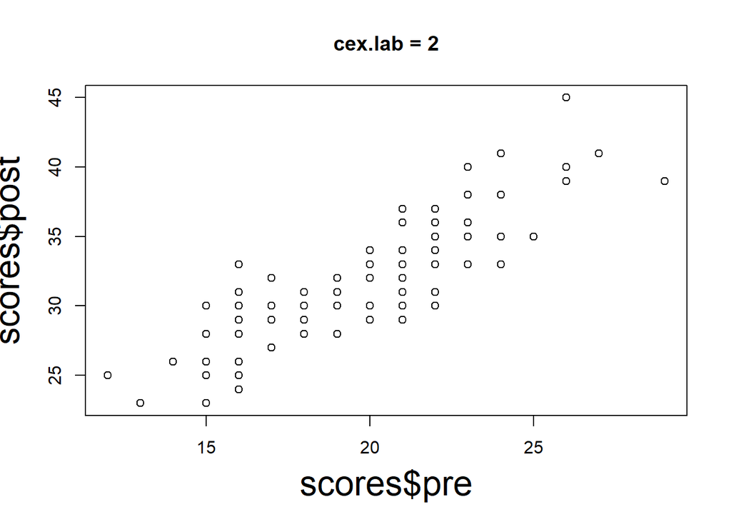

```r
plot(scores$pre,
     scores$post,
     main = "cex.lab = 2",
     cex.lab = 2)
```

#### Title

Use `cex.main` to change the size of the title.

*Code*:

```
plot(x,
     y,
     cex.main = scale)
```

*Example*

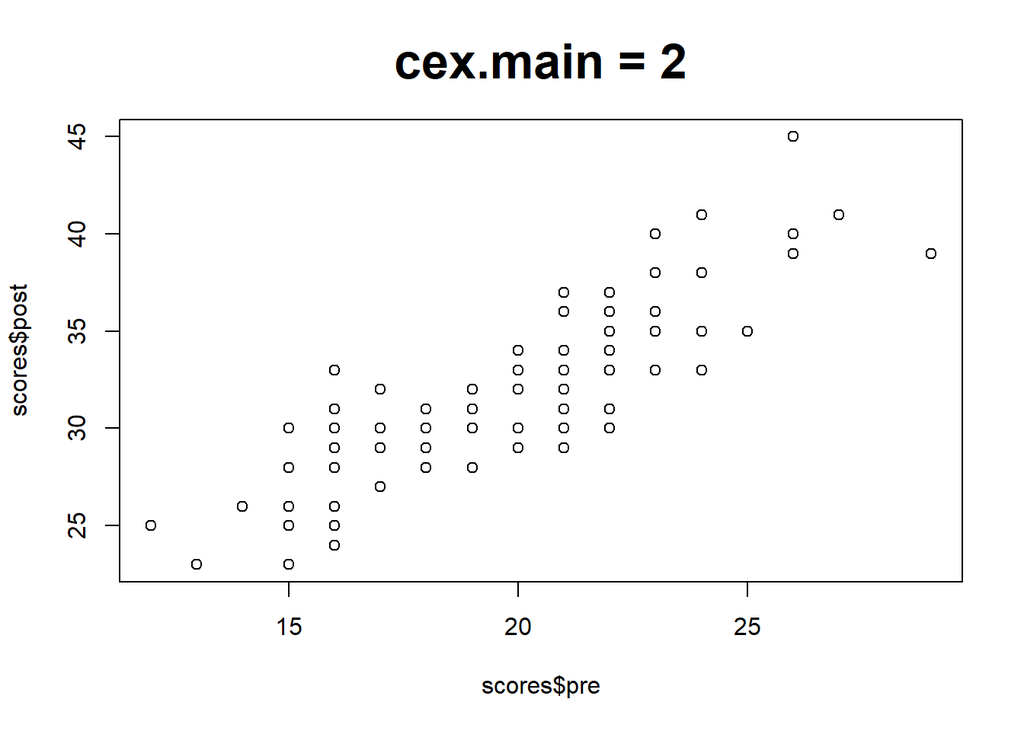

```r
plot(scores$pre,
     scores$post,
     main = "cex.main = 2",
     cex.main = 2)
```

### Color

The basic plots are white with black outlines or shades of gray, which is pretty boring.

R has a bunch of colors that you can use. [Here](http://www.stat.columbia.edu/~tzheng/files/Rcolor.pdf) is a website with a list of all of the default R colors. Note that there is a weird title page, and you need to scroll down to see the color options.

You can also use hex codes using the format `"#code"` to get a custom color. [Here](https://www.color-hex.com/) is a good website for finding hex codes.

*Basic Code*:

```
plot_type(data_vectors,
          col = "color_name")
```

#### All one color

Let’s plot the pre and post-test scores. We’ll use a hex code to make them hot pink and fill them in, so we can see the color better.

*Example*:

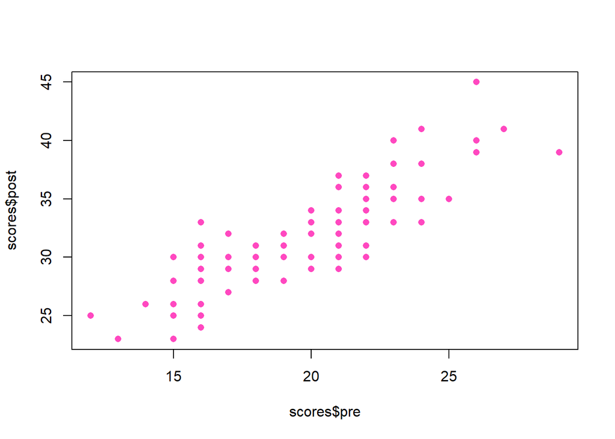

```r
plot(scores$pre,
     scores$post,
     pch = 16,
     col = "#ff48c0")
```

#### Color patterns

You can enter a vector of color names and R will cycle through them as it makes each part of the graph.

*Example*:

Let’s redo the side-by-side score bar graph so that the pre-test scores are blue and the post-test scores are green

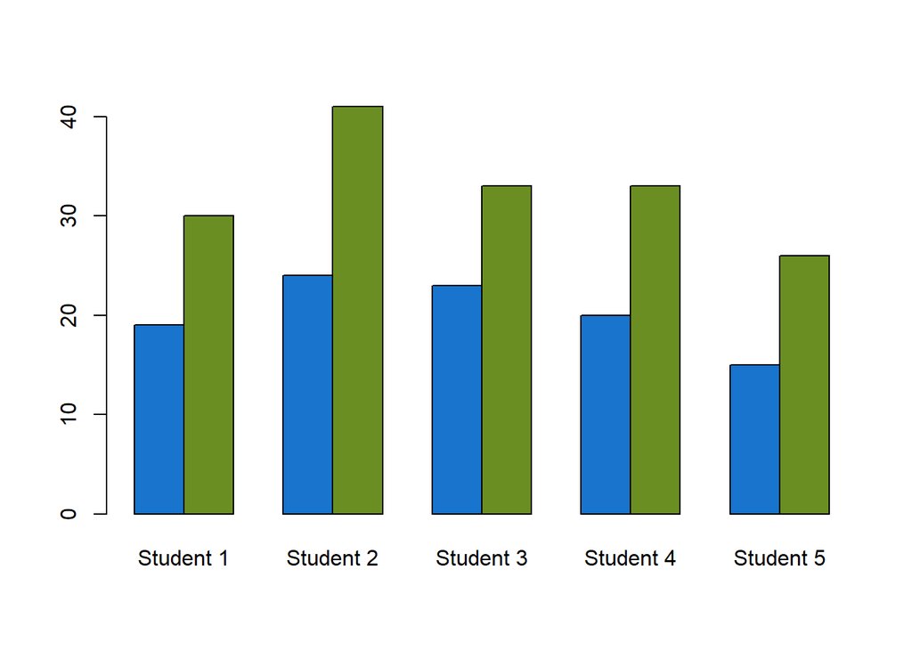

```r
barplot(score_matrix,
        beside = TRUE,
        names.arg = paste("Student", 1:5),
        col = c("dodgerblue3", "olivedrab"))
```

#### A vector of colors assigned to each data point

If you have a color associated with a specific data point, you can simply call that vector, and each point will be the right color.

If you’re going to rearrange your data, make sure the color vector is a variable in the same data frame, so the colors also get rearranged.

*Example*:

Let’s plot the “grade” and “score” values from the *data* data set and color each student’s point the color listed in their row of the data set. Again, I’ll fill them in and make them bigger, so we can see it better.

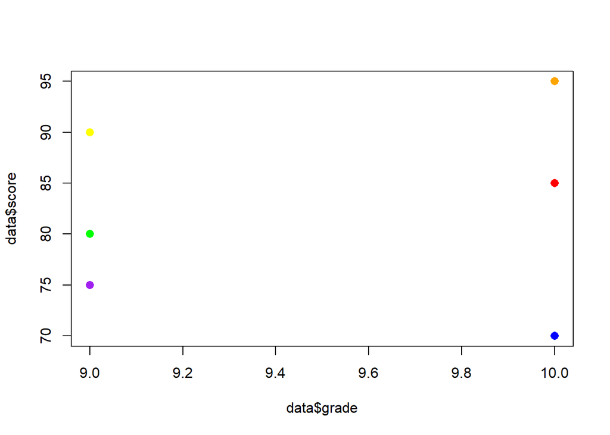

```r
plot(data$grade,
     data$score,
     pch = 16,
     cex = 1.25,
     col = data$color)
```

#### Histogram Borders

The `col` option changes the fill of histogram bars, and the `border` option changes the color of the lines outlining the bars.

*Code*: `hist(vector, border = "color")`

*Example*:

Let’s make a histogram of the pre-test scores where the bars are gold and the border lines are dark orange

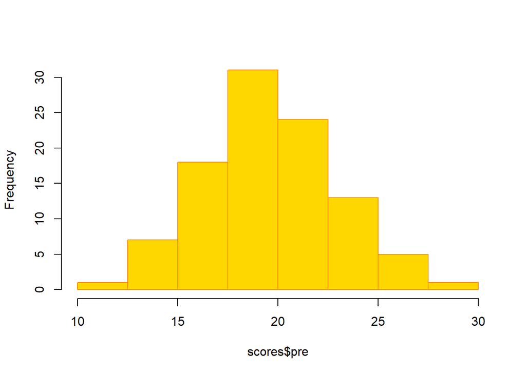

```r
hist(scores$pre,
     breaks = seq(10, 30, 2.5),
     main = "",
     col = "gold",
     border = "darkorange")
```

#### Custom Color Continuums

You can create a color ramp using the `colorRampPalette` command. Define a new object using the command with a vector of colors you want to form the basis of the color scale. It’ll creat a function. To use the new function, specify the number of points you want on the color scale, and it creates a new vector of that length with colors moving progressively from the starting color through the end color.

You can use as many colors as you’d like in your color vector, but you need at least two (otherwise, you’d just name that one color).

*Code*:

```
# Create function
  ramp_function <- colorRampPalette(color_vector)

# Use function
  ramp_function(length)
```

*Example*:

Let’s make a bar graph where the bars go from white to black

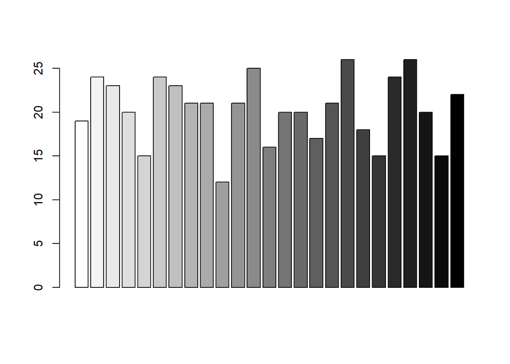

```r
grayscale <- colorRampPalette(c("white", "black"))

barplot(scores$pre[1:25],
        col = grayscale(25))
```

*Example*:

Let’s put some purple in the middle

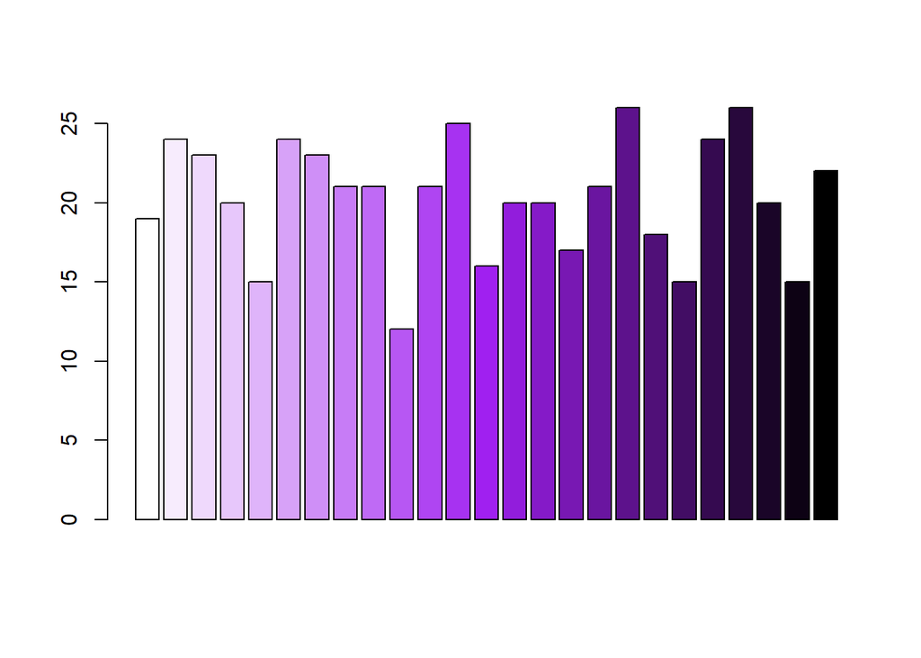

```r
purplescale <- colorRampPalette(c("white", "purple", "black"))

barplot(scores$pre[1:25],
        col = purplescale(25))
```

#### Premade Color Continuums

R has some color pallets that you can use to make nice continuums. Just specify have many colors you need, and it’ll stretch the colors across the spectrum.

1. Rainbow

*Code*:

```
plot_type(data,
          col = rainbow(n))
```

*Example*:

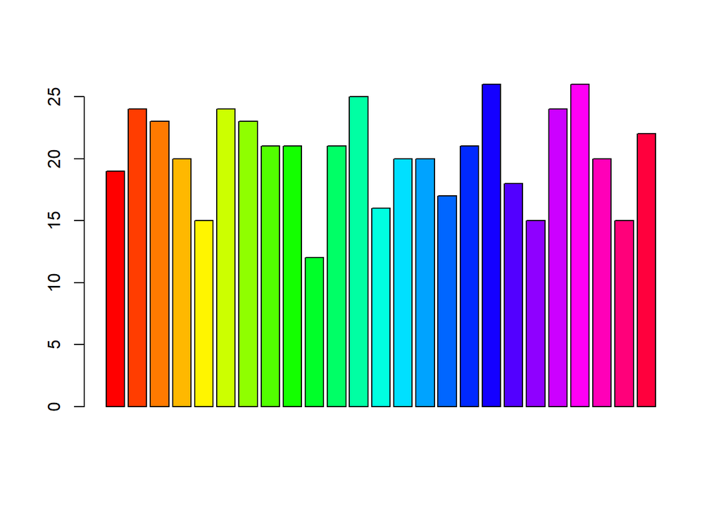

```r
barplot(scores$pre[1:25],
        col = rainbow(25))
```

2. Heat Colors

*Code*:

```
plot_type(data,
          col = heat.colors(n))
```

*Example*:

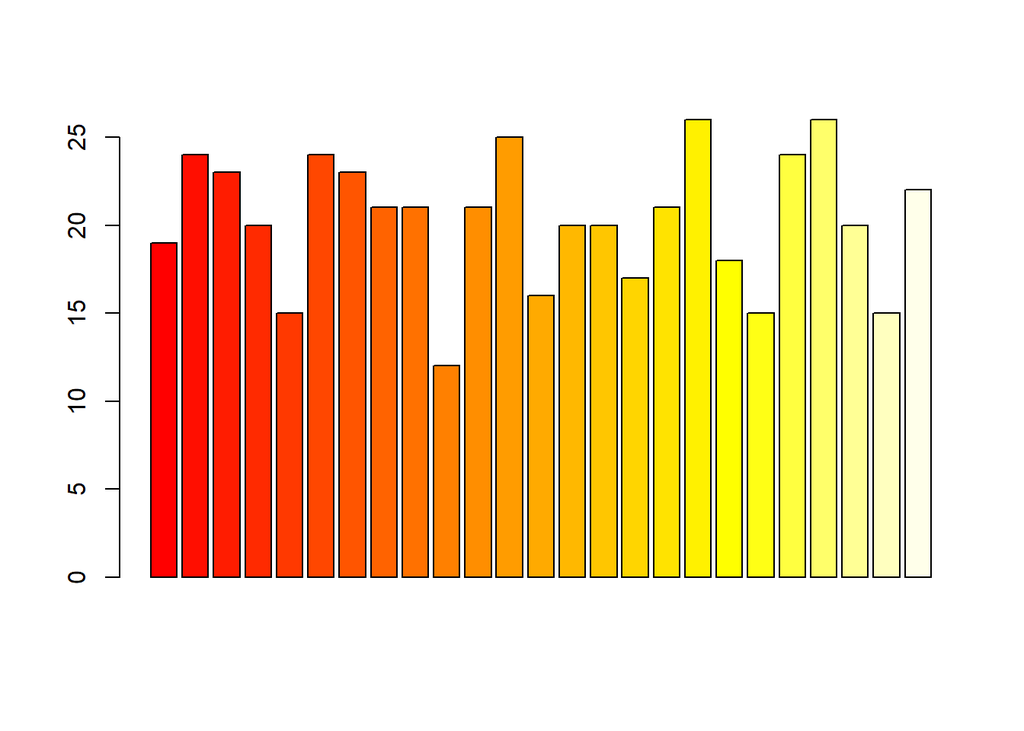

```r
barplot(scores$pre[1:25],
        col = heat.colors(25))
```

3. Terrain Colors

*Code*:

```
plot_type(data,
          col = terrain.colors(n))
```

*Example*:

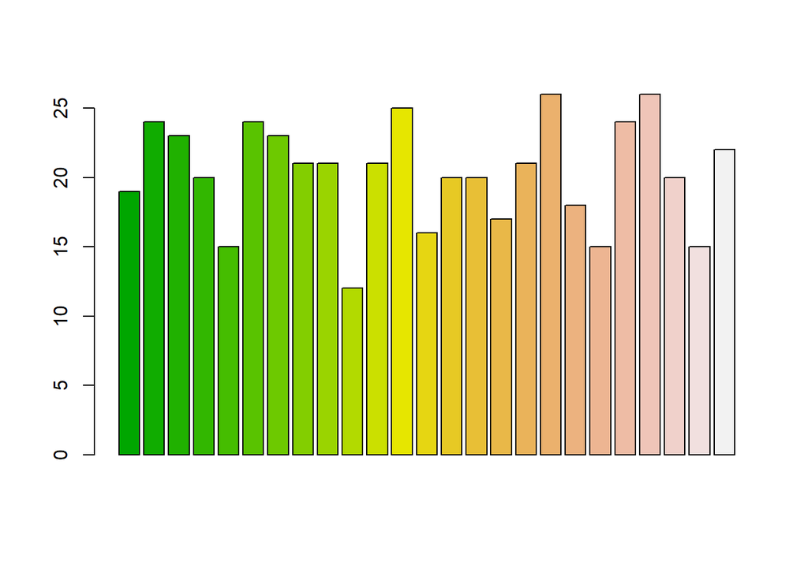

```r
barplot(scores$pre[1:25],
        col = terrain.colors(25))
```

4. Topographical Colors

*Code*:

```
plot_type(data,
          col = topo.colors(n))
```

*Example*:

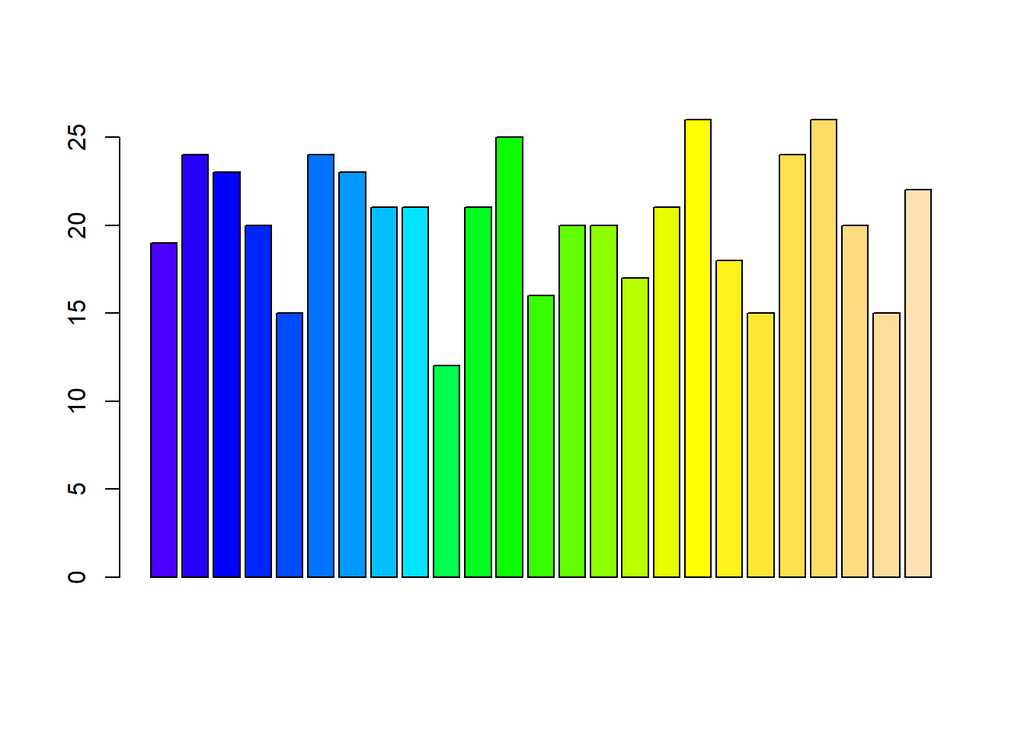

```r
barplot(scores$pre[1:25],
        col = topo.colors(25))
```

5. Cyan-Magenta Colors

*Code*:

```
plot_type(data,
          col = cm.colors(n))
```

*Example*:

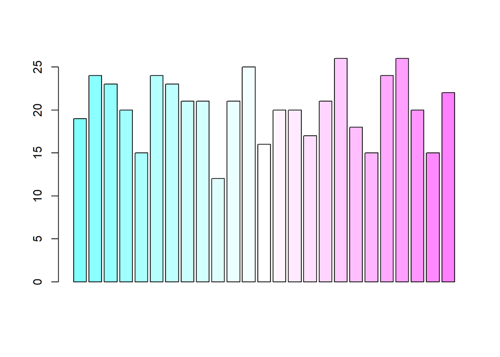

```r
barplot(scores$pre[1:25],
        col = cm.colors(25))
```

## Lines

You can add different kinds of lines to your graphs. All of these line types require a pre-existing plot and cannot be plotted on their own.

You can create an empty plot by specifying the x and y limits and ploting a single point in the range using the option `type = "n"`

*Code*:

```
plot(x,
     y,
     xlim = c(xmin, xmax),
     ylim = c(ymin, ymax),
     type = "n")
```

Once you have a plot, you can add as many lines as you want.

### Straight Lines

Use the `abline` function to draw straight lines.

#### y = mx + b

You can plot a straight line by specifying an intercept and a slope value.

*Code*: `abline(intercept, slope)`

*Example*:

Let’s draw the identity line y = x on our scatter plot or pre- and post-test scores to see the shift in scores between the two occasions. The intercept is 0, and the slope is 1.

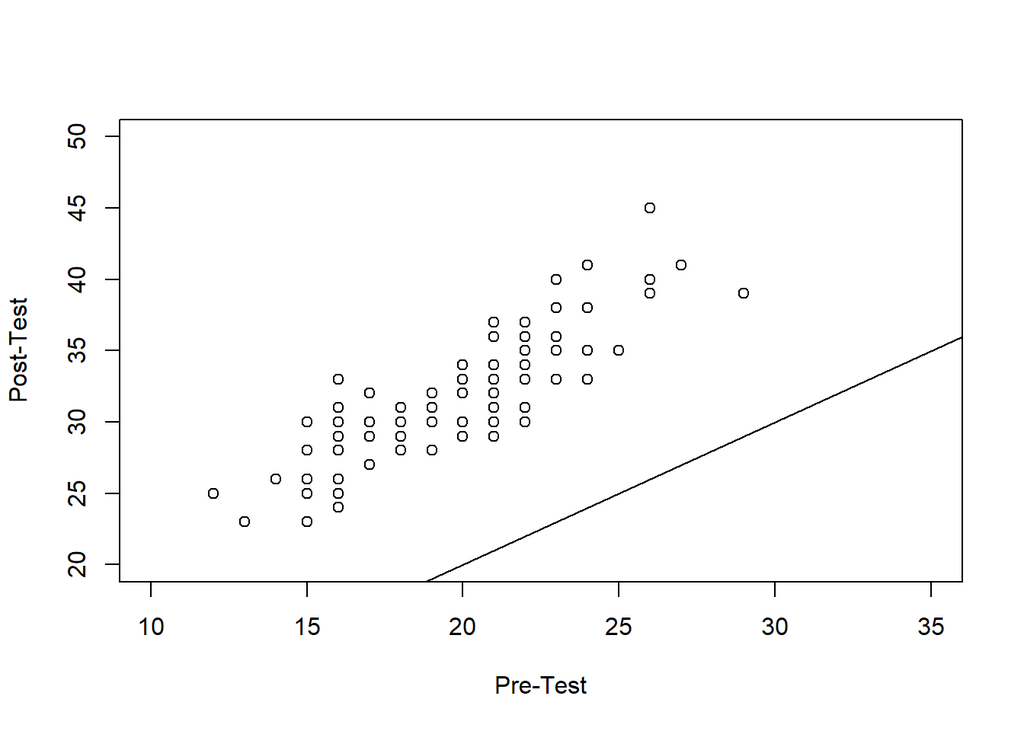

```r
# Create a plot window first
  plot(scores$pre,
       scores$post,
       xlim = c(10, 35),
       ylim = c(20, 50),
       xlab = "Pre-Test",
       ylab = "Post-Test")

# Plot the line on top
  abline(0, 1)
```

#### Vertical Lines

*Code*: `abline(v = xval)`

*Example*:

Let’s make a vertical line at x = 25 on our scores scatterplot to see which students earned at least a 50% on the pre-test.

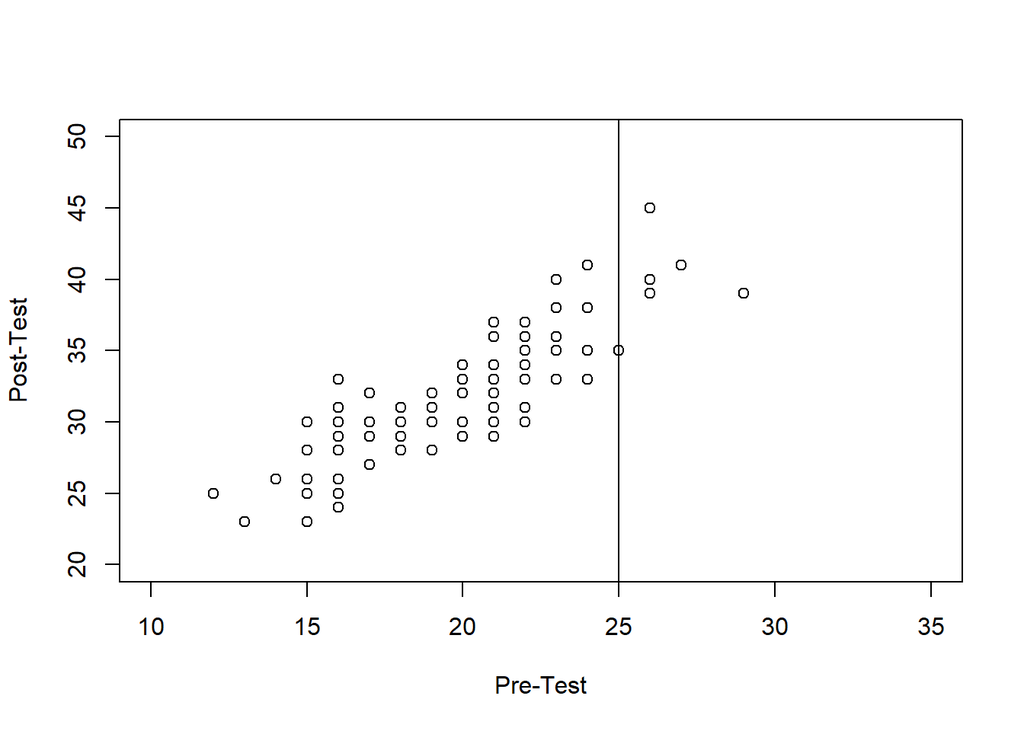

```r
# Create a plot window first
  plot(scores$pre,
       scores$post,
       xlim = c(10, 35),
       ylim = c(20, 50),
       xlab = "Pre-Test",
       ylab = "Post-Test")

# Plot the line on top
  abline(v = 25)
```

#### Horizontal Lines

*Code*: `abline(h = yval)`

*Example*:

Let’s make a horizontal line at y = 25 on our scores scatterplot to see which students earned at least a 50% on the post-test.

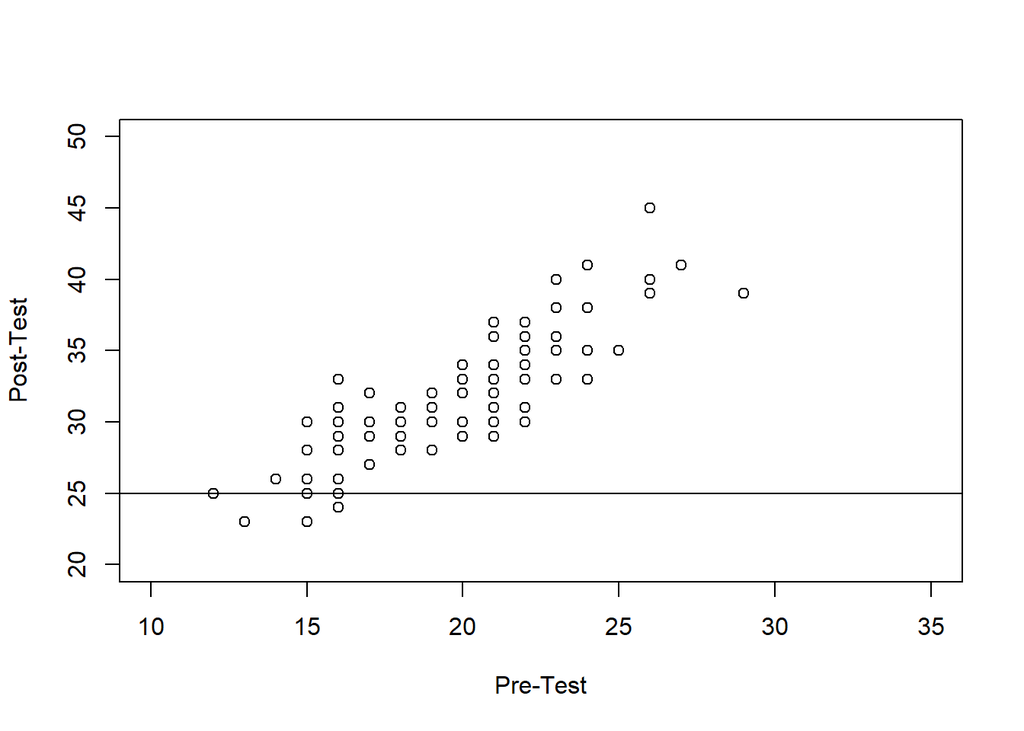

```r
# Create a plot window first
  plot(scores$pre,
       scores$post,
       xlim = c(10, 35),
       ylim = c(20, 50),
       xlab = "Pre-Test",
       ylab = "Post-Test")

# Plot the line on top
  abline(h = 25)
```

### Regression Lines

**See the Analysis in R file for more details on regressions.**

You can plot a regression line by either calling an existing regression object or by putting the regression model directly into the argument.

#### Model in the argument

*Code*: `abline(lm(y ~ x))`

*Example*:

Let’s add a regression line to our scores scatter plot.

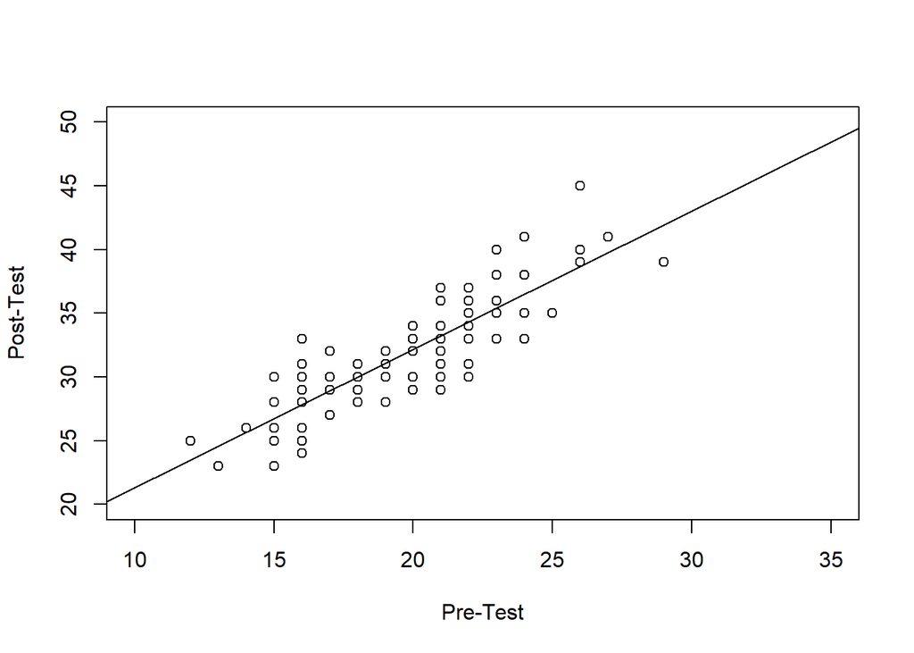

```r
# Create a plot window first
  plot(scores$pre,
       scores$post,
       xlim = c(10, 35),
       ylim = c(20, 50),
       xlab = "Pre-Test",
       ylab = "Post-Test")

# Plot the line on top
  abline(lm(scores$post ~ scores$pre))
```

#### Regression Object

*Code*: `abline(reg_object)`

*Example*:

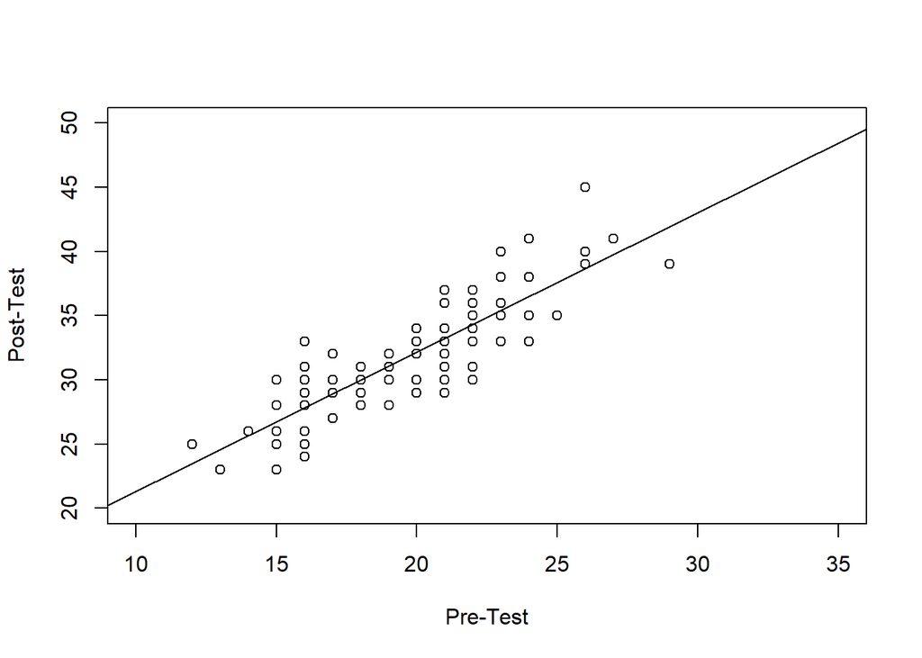

```r
# create a regression object
  score_reg <- lm(scores$post ~ scores$pre)

# Create a plot window first
  plot(scores$pre,
       scores$post,
       xlim = c(10, 35),
       ylim = c(20, 50),
       xlab = "Pre-Test",
       ylab = "Post-Test")

# Plot the line on top
  abline(score_reg)
```

### Lines Connecting Points

If you’re using either the `plot` or `points` functions, you can connect the data points with a line using the `type` option.

*Code*:

```
plot(x,
     y,
     type = "option")
```

OR

```
points(x,
       y,
       type = "option")
```

The image below shows the different line options.

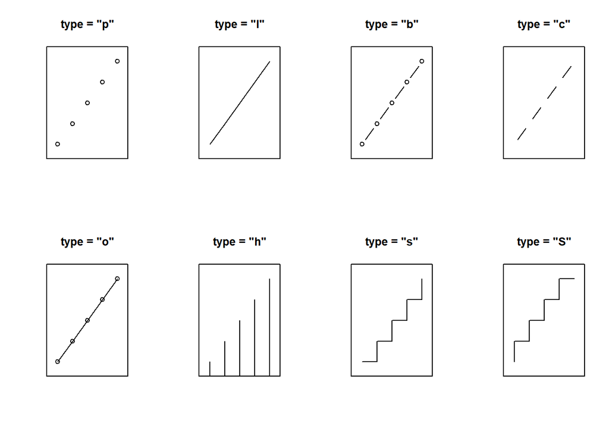

*Default*: `type = "p"`

**Warning**: The points will connect in the order in which they are plotted, so you’ll want to arrange the x values in the order you want first.

*Example*:

We’ll plot a set of students’ scores and the time (in hours) they took to complete the test with and without sorting first. The *time* data set is printed below

| score | time |
| --- | --- |
| 25 | 1.677 |
| 29 | 1.426 |
| 29 | 1.739 |
| 31 | 1.695 |
| 27 | 1.393 |
| 25 | 1.271 |
| 27 | 1.567 |
| 20 | 1.112 |
| 30 | 1.707 |
| 25 | 1.617 |

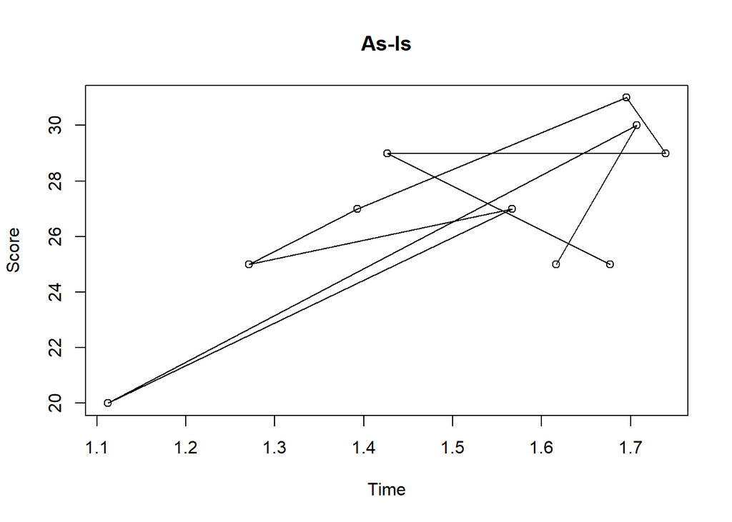

```r
# Plotting the data as-is
  plot(time$time,
       time$score,
       xlab = "Time",
       ylab = "Score",
       type = "o",
       main = "As-Is")
```

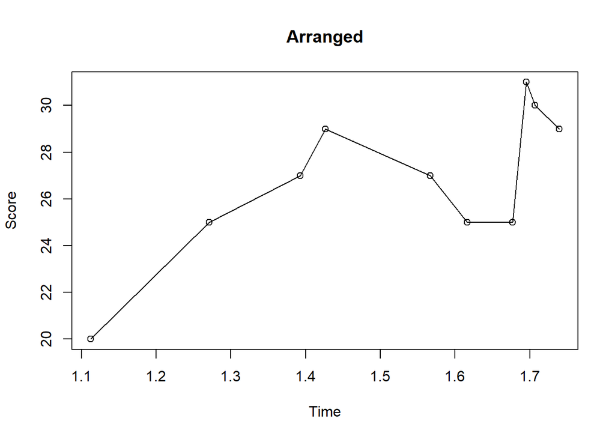

```r
# Arrange by pre-test score
  time %<>% arrange(time)

# Plot the arranged data
  plot(time$time,
       time$score,
       xlab = "Time",
       ylab = "Score",
       type = "o",
       main = "Arranged")
```

### Density Lines

You can graph a density line for a given vector using the following code:

*Code*: `lines(density(vector))`

#### Adding a density line on top of a histogram.

*Example*:

Let’s make a histogram of the pre-test scores with a density line on top.

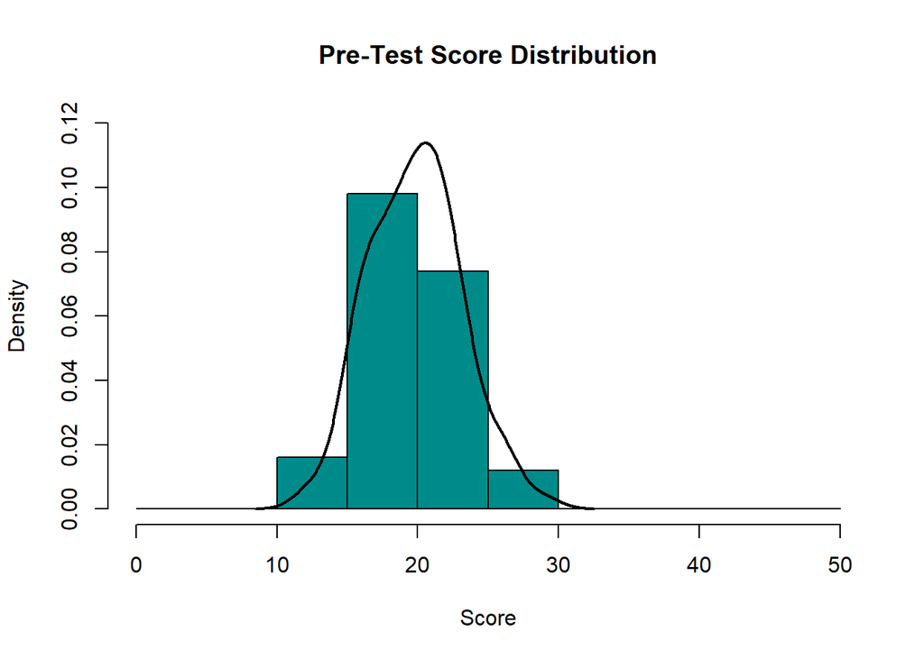

```r
hist(scores$pre,
     freq = FALSE,
     col = "darkcyan",
     xlab = "Score",
     xlim = c(0, 50),
     breaks = seq(0, 50, 5),
     ylim = c(0, 0.12),
     main = "Pre-Test Score Distribution")
lines(density(scores$pre),
      lwd = 2)
```

#### Graphing just the density line(s)

You can’t just plot a line. You need an existing plot to put the line on. You can get just the line the show by plotting a histogram where the bars and lines are white.

*Example*:

Let’s graph the density lines for the pre- and post tests on the same set of axes.

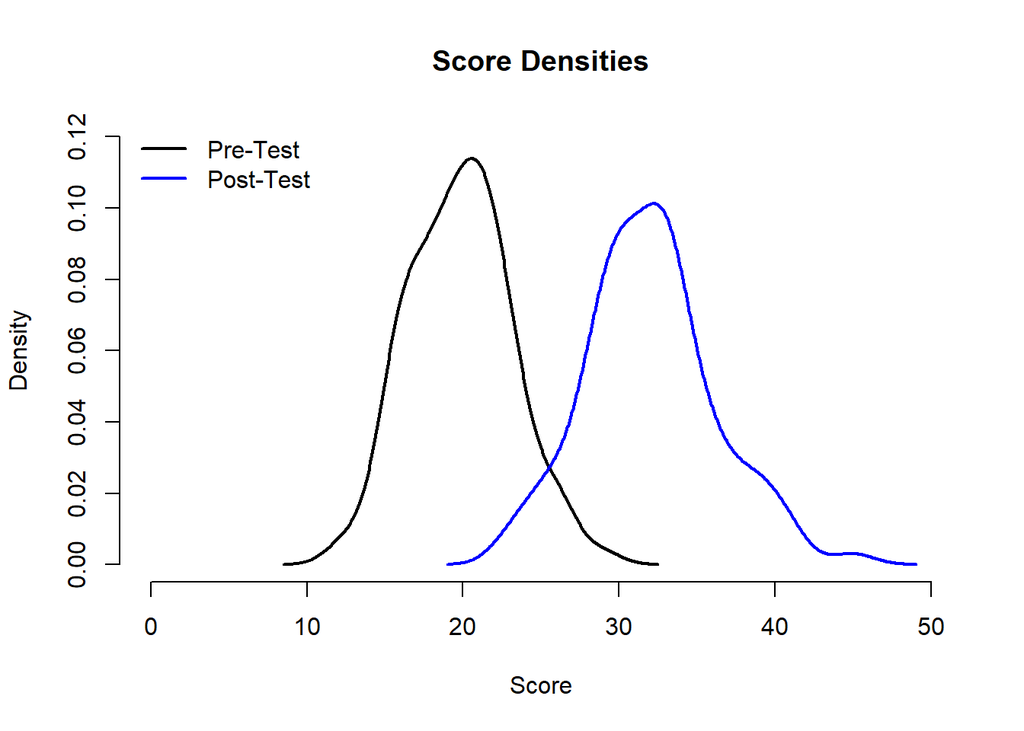

```r
hist(scores$pre,
     freq = FALSE,
     col = "white",
     border = "white",
     xlab = "Score",
     xlim = c(0, 50),
     ylim = c(0, 0.12),
     main = "Score Densities")
lines(density(scores$pre),
      lwd = 2)
lines(density(scores$post),
      col = "blue",
      lwd = 2)
legend("topleft",
       legend = c("Pre-Test", "Post-Test"),
       lwd = 2,
       col = c("black", "blue"),
       bty = "n")
```

### Line Options

You can make your lines different colors, widths, and patterns.

#### Color

Use the same `col` argument you used for changing the color of the data points.

*Code*: `abline(data, col = "color_name")`

*Example*:

Let’s make our scores regression line purple.

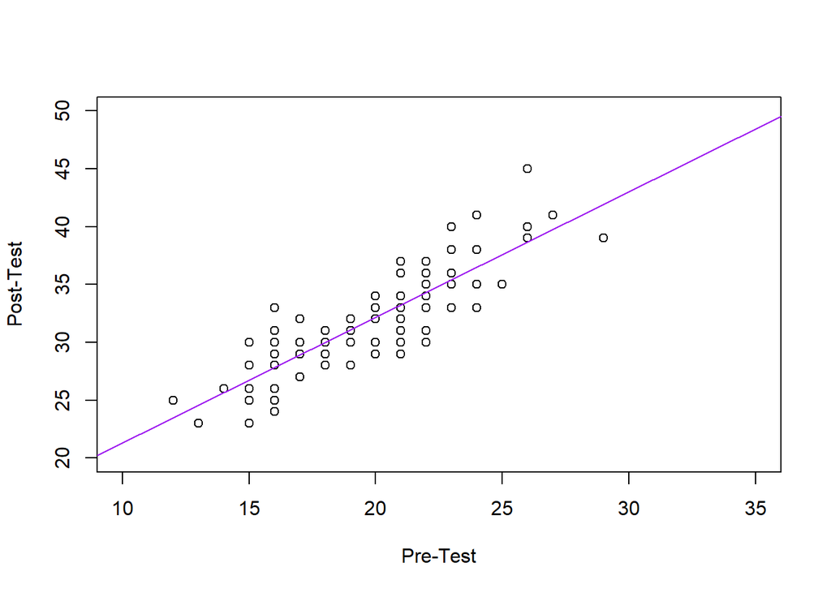

```r
# Create a plot window first
  plot(scores$pre,
       scores$post,
       xlim = c(10, 35),
       ylim = c(20, 50),
       xlab = "Pre-Test",
       ylab = "Post-Test")

# Plot the line on top
  abline(lm(scores$post ~ scores$pre),
         col = "purple")
```

#### Width

Use the `lwd` option to change the width of a line. The number you enter will scale the normal line width.

*Code*: `abline(data, lwd = number)`

*Example*:

Let’s triple the width of our regression line.

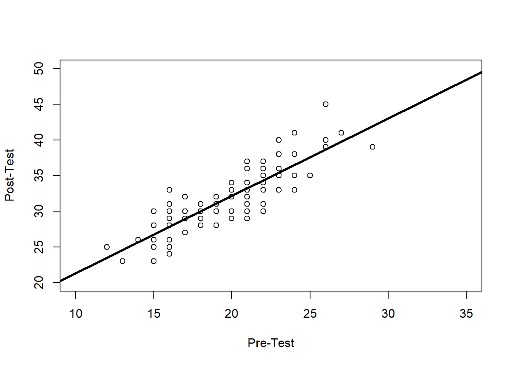

```r
# Create a plot window first
  plot(scores$pre,
       scores$post,
       xlim = c(10, 35),
       ylim = c(20, 50),
       xlab = "Pre-Test",
       ylab = "Post-Test")

# Plot the line on top
  abline(lm(scores$post ~ scores$pre),
         lwd = 3)
```

#### Pattern

You can use the `lty` option to change the line pattern. The options are shown in the image below.

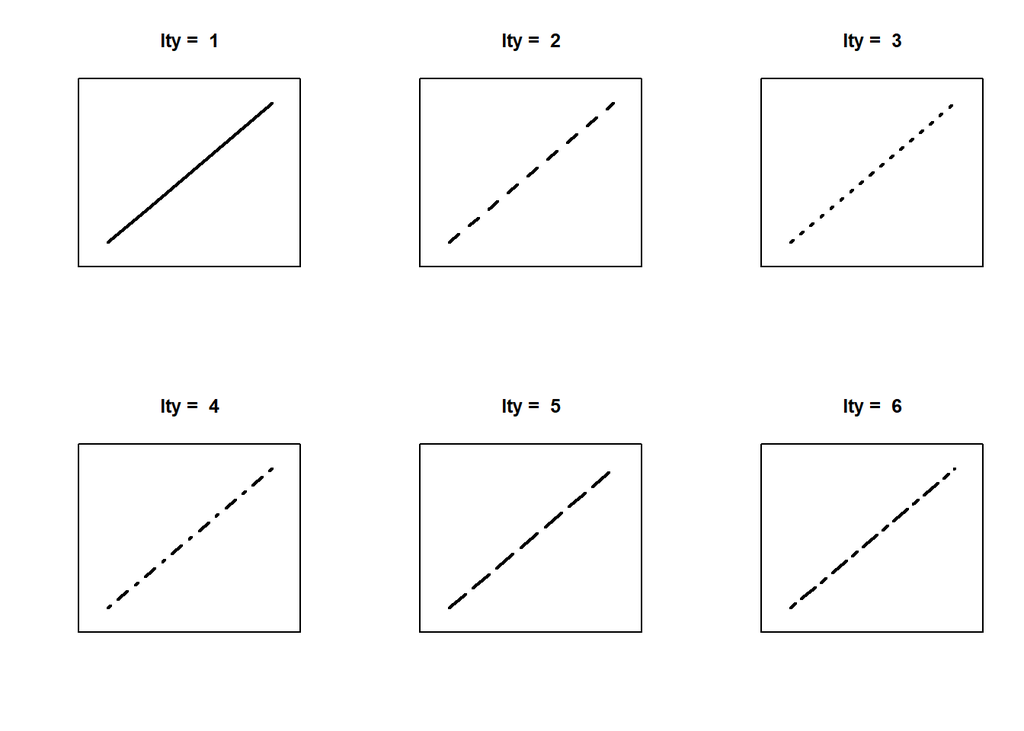

*Default*: `lty = 1`

*Example*:

Let’s make our regression line dashed.

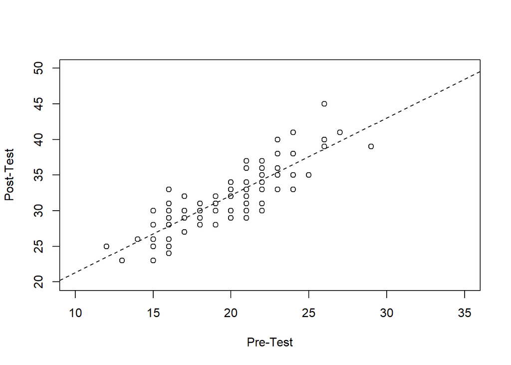

```r
# Create a plot window first
  plot(scores$pre,
       scores$post,
       xlim = c(10, 35),
       ylim = c(20, 50),
       xlab = "Pre-Test",
       ylab = "Post-Test")

# Plot the line on top
  abline(lm(scores$post ~ scores$pre),
         lty = 2)
```

## Legends

Lengeds are really helpful if you want to have multiple sets of data in the same plot and need to distinguish between them using different colors and shapes.

Legends are also good for adding correlations to scatter plots, adding SDs to histograms, etc.

You can’t make a legend without an existing plot. Use the same `type = "n"` trick shown in the Lines section to create a blank plot if you just want the legend.

### Basics

To create a legend, you need to specify the location & the text (which can be a vector). You can either specify explicit x & y coordinates or use one of the location keywords. I like to just use the keywords for general legends and inset them a bit. The x & y coordinate option is good for labeling individual points on a scatterplot.

#### Location Keyword

The location keyword options are presented below.

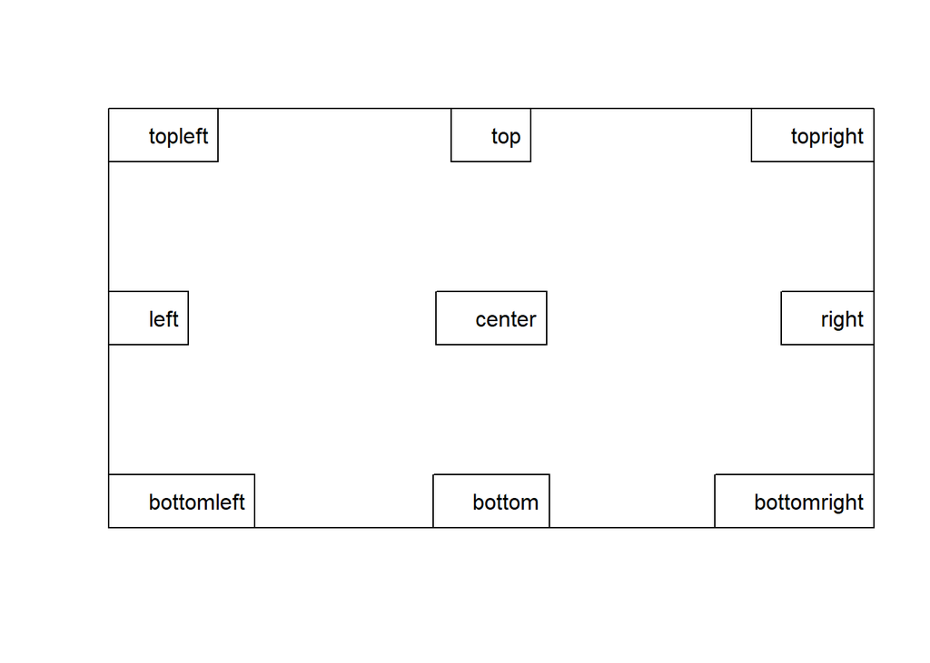

*Code*: `legend("location", legend = "Text")`

*Example*:

Lets plot a histogram of the pre-test scores and use a legend to add the mean and the SD of the scores.

I’ll use the `paste` command to combine the text “SD =” with the rounded SD for the scores and “Mean =” with the rounded mean. If you don’t round the number, it will print a lot of digits.

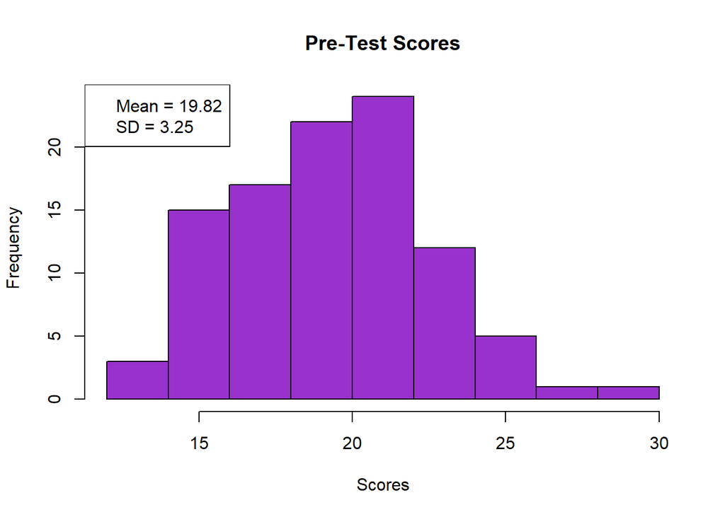

```r
hist(scores$pre,
     xlab = "Scores",
     col = "darkorchid",
     main = "Pre-Test Scores")
legend("topleft",
       legend = c(paste("Mean =", round(mean(scores$pre), 2)),
                  paste("SD =", round(sd(scores$pre), 2))))
```

#### Coordinates

You can specify a set of x and y coordinates, and the upper left corner of the legend box will be placed on that point.

*Code*: `legend(x, y, legend = "Text")`

*Example*:

Let’s take the test scores scatter plot and label the point for the student who scored the highest on the pre-test.

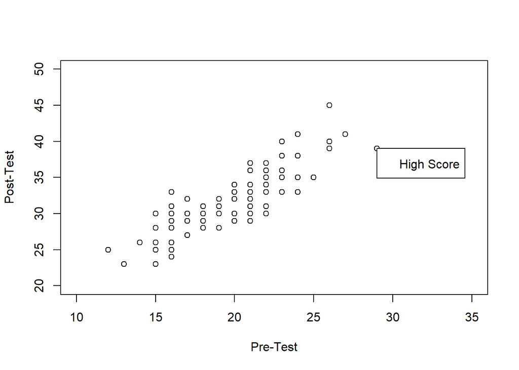

```r
# Create a plot window first
  plot(scores$pre,
       scores$post,
       xlim = c(10, 35),
       ylim = c(20, 50),
       xlab = "Pre-Test",
       ylab = "Post-Test")


# Add Legend
  legend(max(scores$pre),
         scores$post[which(scores$pre == max(scores$pre))],
         legend = "High Score")
```

### Lines & Symbols

You may have noticed in the Basics tab that the text is shifted to the side in the legend boxes. This is because R is making space for a symbol that we haven’t specified. You can use the same data point symbols and line options that are presented in the Scatterplot and Line sections.

#### Lines

The same `col`, `lty`, and `lwd` options discussed in the Lines section still apply here. Make sure that you list the legend text extries and the line options in the same order.

*Code*:

```
legend("location",
       legend = "Text",
       lwd = width_scale,
       lty = line_option,
       col = "color_name")
```

*Example*:

Let’s plot our scores along with a regression line and the identity line, for comparison.

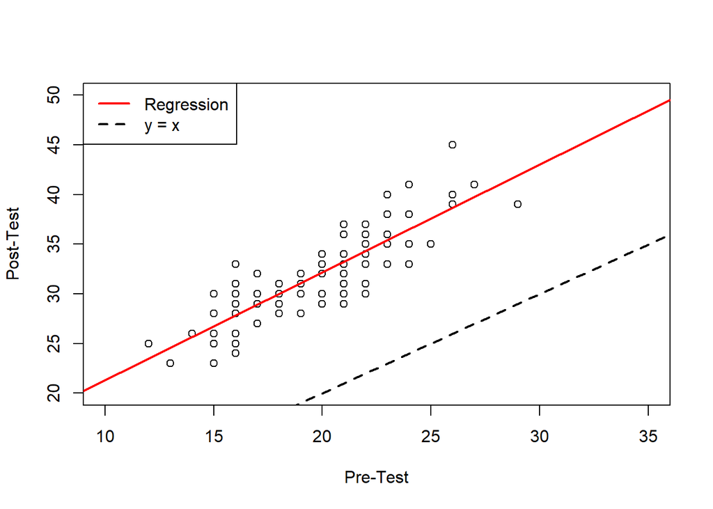

```r
# Create a plot window first
  plot(scores$pre,
       scores$post,
       xlim = c(10, 35),
       ylim = c(20, 50),
       xlab = "Pre-Test",
       ylab = "Post-Test")

# Plot the regression line
  abline(lm(scores$post ~ scores$pre),
         lwd = 2,
         col = "red")

# Plot the identity line
  abline(0,
         1,
         lwd = 2,
         lty = 2)

# Add Legend
  legend("topleft",
         legend = c("Regression", "y = x"),
         lwd = 2,
         lty = c(1, 2),
         col = c("red", "black"))
```

#### Symbols

The same `pch` options apply to the legend.

*Code*:

```
legend("location",
       legend = "Text",
       pch = option,
       col = "color_name")
```

*Example*:

Let’s plot the “grade” and “score” values from the *data* data set and use a legend to specify which data point belongs to which student.

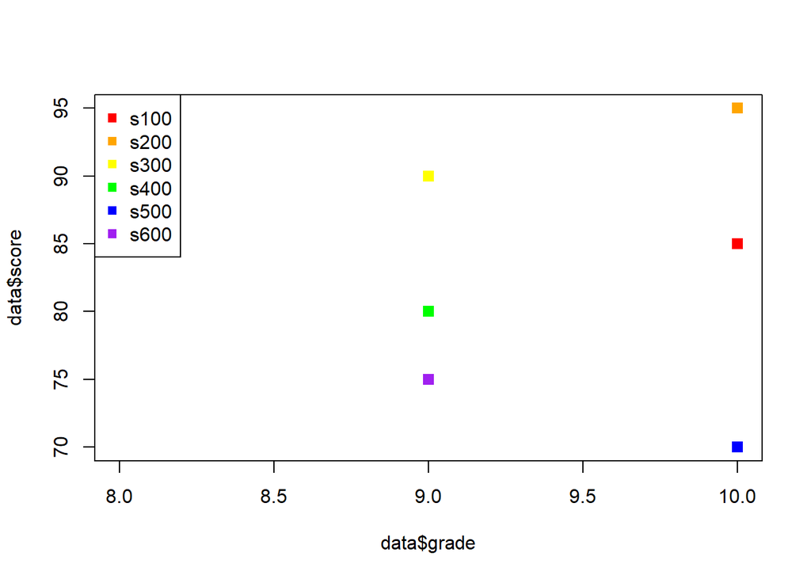

```r
# Plot Data
  plot(data$grade,
       data$score,
       xlim = c(8, 10),
       pch = 15,
       cex = 1.25,
       col = data$color)

# Legend
  legend("topleft",
         legend = data$id,
         pch = 15,
         col = data$color)
```

### Text Color

The `col` option only changes the color of the line or symbol next to your text.

Use the `text.col` option to change the color of your text.

If you want both the symbol/line and the text to be the same color, you’ll need to enter both options.

*Code*:

```
legend("location",
       legend = "Text",
       text.col = "color")
```

*Example*:

Let’s take out the symbols from the grades and scores plot and make the student IDs the corresponding colors instead.

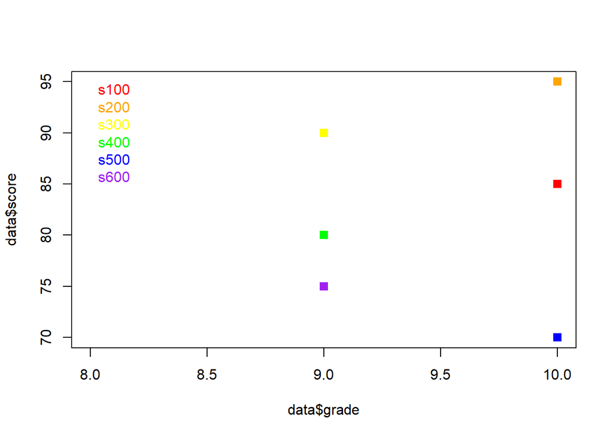

```r
# Plot Data
  plot(data$grade,
       data$score,
       xlim = c(8, 10),
       pch = 15,
       cex = 1.25,
       col = data$color)

# Legend
  legend("topleft",
         legend = data$id,
         text.col = data$color,
         bty = "n")
```

### Border

The `bty` option is used to change borders (See the Window Options section for more details).

The only border options allowed for legends are the default full border `bty = "o"` and no border `bty = "n"`. If you want the border, there’s no need to write any code. If you don’t want a border, use the “n” option.

*Code*:

```
legend(legend = "text",
       bty = "n")
```

*Example*:

Let’s add the correlation between the pre- and post-test scores as a legend with no border

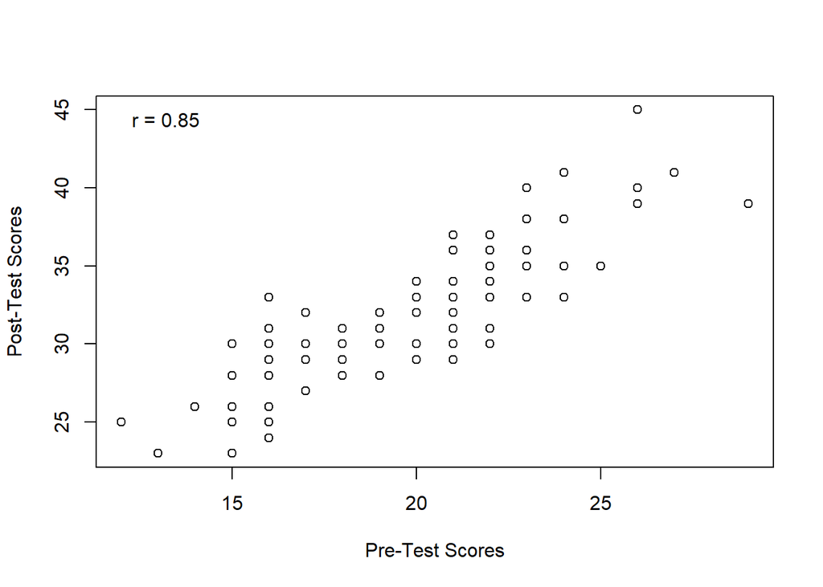

```r
plot(scores$pre,
     scores$post,
     xlab = "Pre-Test Scores",
     ylab = "Post-Test Scores")
legend("topleft",
       legend = paste("r =", round(cor(scores$pre, scores$post), 2)),
       bty = "n")
```

### Size

Just like with the plots, use the `cex` options to change the size of elements of your legend.

#### Symbols and Text

The `cex` option will change the size of both the symbols and the text in your legend.

*Code*:

```
legend("location",
       legend = "Text",
       cex = scale)
```

*Example*:

Let’s double the size of the legend elements for the grades and scores scatter plot legend.

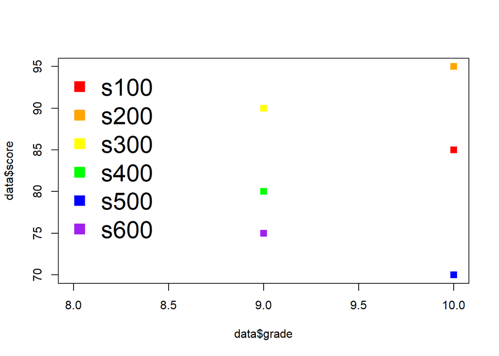

```r
# Plot Data
  plot(data$grade,
       data$score,
       xlim = c(8, 10),
       pch = 15,
       cex = 1.25,
       col = data$color)

# Legend
  legend("topleft",
         legend = data$id,
         col = data$color,
         pch = 15,
         cex = 2,
         bty = "n")
```

#### Only Symbols

Use the `pt.cex` option to change only the size of the legend symbols.

*Code*:

```
legend("location",
       legend = "Text",
       pt.cex = scale)
```

*Example*:

Let’s double the size of only the symbols for the grades and scores scatter plot legend.

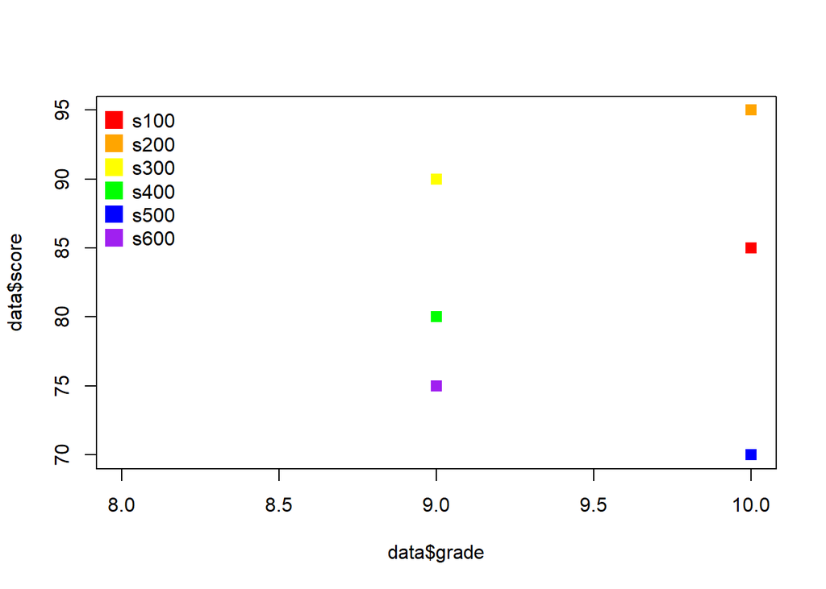

```r
# Plot Data
  plot(data$grade,
       data$score,
       xlim = c(8, 10),
       pch = 15,
       cex = 1.25,
       col = data$color)

# Legend
  legend("topleft",
         legend = data$id,
         col = data$color,
         pch = 15,
         pt.cex = 2,
         bty = "n")
```

#### Only Text

There is no command to only change the size of text and not the symbol. If you want to do that, you need to use both the `cex` option with your desired text size scaling and the `pt.cex` option set to the default value of 1.

*Code*:

```
legend("location",
       legend = "Text",
       cex = text_scale,
       pt.cex = 1)
```

*Example*:

Let’s double the only size of the text for the grades and scores scatter plot legend.

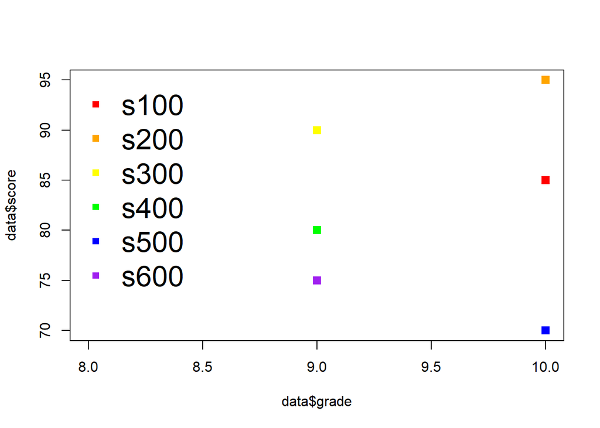

```r
# Plot Data
  plot(data$grade,
       data$score,
       xlim = c(8, 10),
       pch = 15,
       cex = 1.25,
       col = data$color)

# Legend
  legend("topleft",
         legend = data$id,
         col = data$color,
         pch = 15,
         cex = 2,
         pt.cex = 1,
         bty = "n")
```

### Inset

If you don’t want a line or symbol, it can look kind of weird to have the extra space. You can use the `inset` option to move the legend right/left and up/down.

*Code*:

```
legend("location",
       legend = "Text",
       inset = c(horizontal_shift, vertical_shift))
```

*Example*:

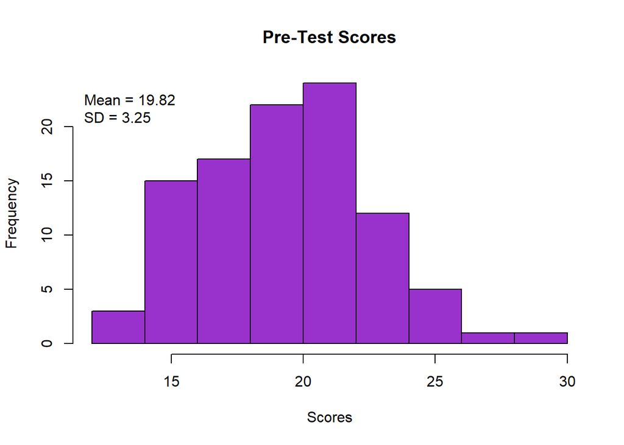

```r
hist(scores$pre,
     xlab = "Scores",
     col = "darkorchid",
     main = "Pre-Test Scores")
legend("topleft",
       legend = c(paste("Mean =", round(mean(scores$pre), 2)),
                  paste("SD =", round(sd(scores$pre), 2))),
       bty = "n",
       inset = c(-0.03, 0.03))
```

### Columns

If you have a lot of entries in your legend, you may want to make multiple columns using the `ncol` option.

Note that the legend entries will fill in column by column.

*Code*:

```
legend("location",
       legend = "Text",
       ncol = number)
```

*Example*:

Let’s make the grades and scores legend two columns.

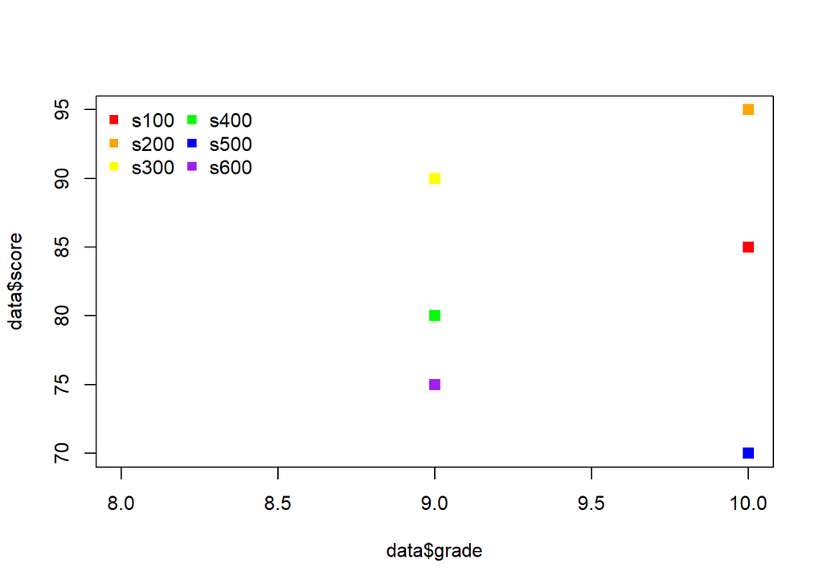

```r
# Plot Data
  plot(data$grade,
       data$score,
       xlim = c(8, 10),
       pch = 15,
       cex = 1.25,
       col = data$color)

# Legend
  legend("topleft",
         legend = data$id,
         col = data$color,
         pch = 15,
         ncol = 2,
         bty = "n")
```

### Horizontal Legends

If you want to have the legend print as rows instead of columns, use the `horiz` option.

*Code*:

```
legend("location",
       legend = "Text",
       horiz = TRUE)
```

*Example*:

Let’s make the grades and scores legend horizontal.

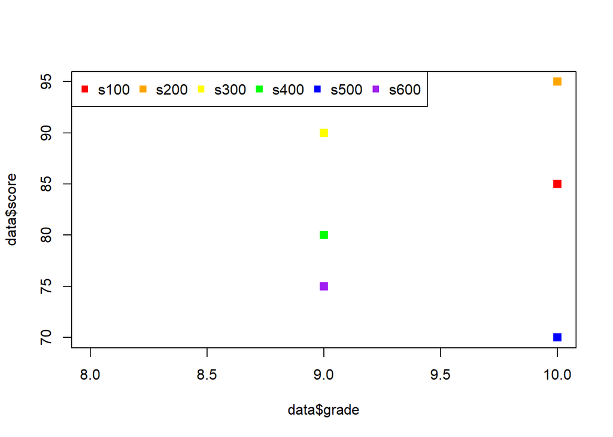

```r
# Plot Data
  plot(data$grade,
       data$score,
       xlim = c(8, 10),
       pch = 15,
       cex = 1.25,
       col = data$color)

# Legend
  legend("topleft",
         legend = data$id,
         col = data$color,
         pch = 15,
         horiz = TRUE)
```

## Window Options

The following options apply to all types of visuals.

You can check the current values for any of these options by typing `par()` into the console.

If you’re going to change a bunch of values and want to be able to get back to the default settings, or if you want to save a certain configuration for later use, you can save the current settings as an object.

*Code*: `settings_object <- par()`

To use that set of window parameters later, simply call upon them in the `par` command before creating a new plot

*Code*: `par(settings_object)`

### Splitting the Window

You can plot multiple graphs in the same plot window. Note that once you change the way the window is partitioned, it will stay that way until you reset it to the default.

*Code*: `par(mfrow = c(rows, columns))`

*Default*: `mfrow = c(1, 1)`

*Example*:

Let’s make side-by-side histograms for the pre- and post-test scores

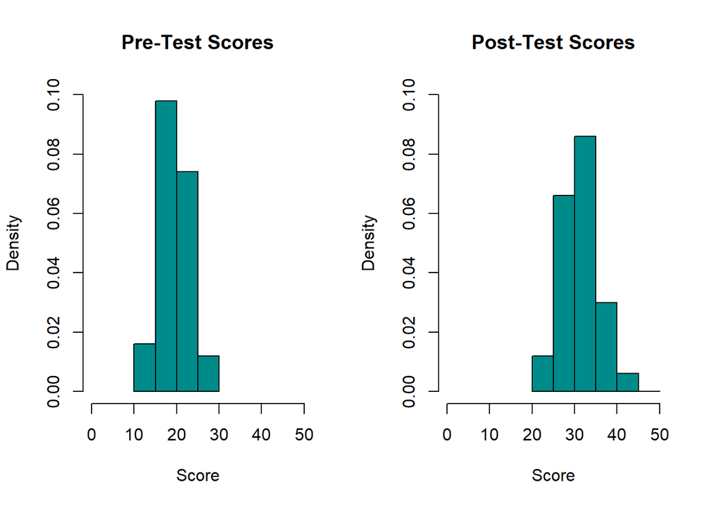

```r
par(mfrow = c(1, 2))

hist(scores$pre,
     freq = FALSE,
     col = "darkcyan",
     xlab = "Score",
     xlim = c(0, 50),
     breaks = seq(min(scores$pre) - (min(scores$pre) %% 5),
                  max(scores$pre) + (5 - (max(scores$pre) %% 5)),
                  5),
     ylim = c(0, 0.1),
     main = "Pre-Test Scores")

hist(scores$post,
     freq = FALSE,
     col = "darkcyan",
     xlab = "Score",
     xlim = c(0, 50),
     breaks = seq(min(scores$post) - (min(scores$post) %% 5),
                  max(scores$post) + (5 - (max(scores$post) %% 5)),
                  5),
     ylim = c(0, 0.1),
     main = "Post-Test Scores")
```

#### Resetting the Window

When you have a split window, the next thing you plot will go into the next open space. If you want to start over with a fresh plot instead of adding to what’s already there, you can change the `mfrow` option in the `par` command.

*Example*:

Let’s say I’ve plotted five historgrams in a windown that’s split into two rows and three columns, as seen below.

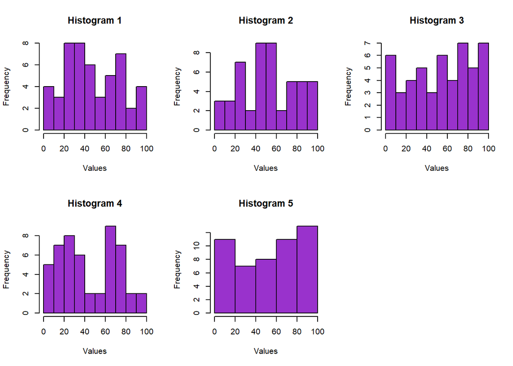

When I plot the next graphs, they’ll go into the remaining space and spill over to a new window. Let’s say I want to make scatter plots of the pre- and post-test scores where I’ve split the data into five groups. If I don’t reset the window, it’ll look like this:

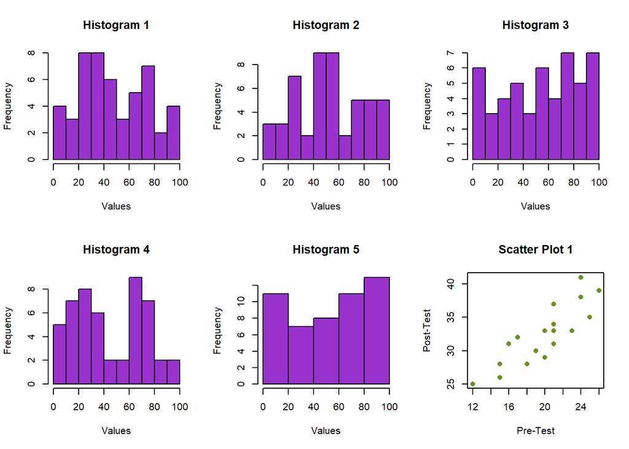

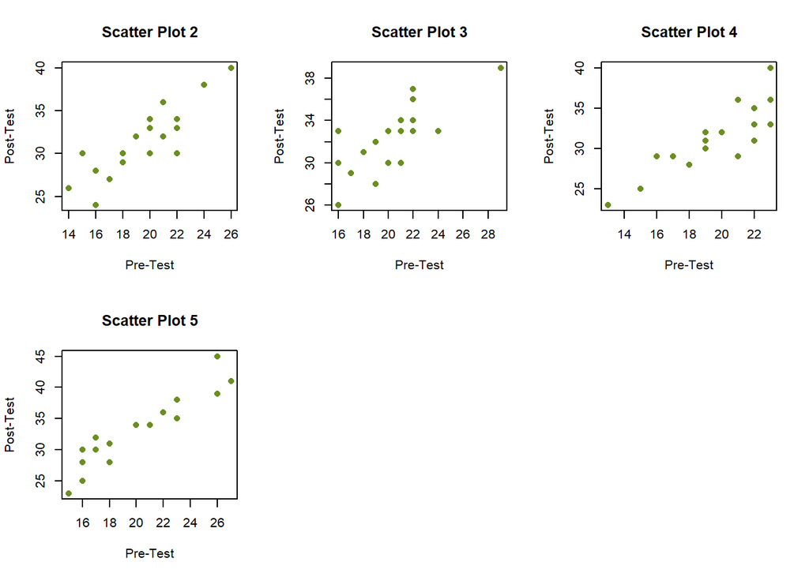

I’ll reset the window by reusing the `mfrow` command, even though I’m not changing the number of rows or columns, and it’ll start from the top left section again.

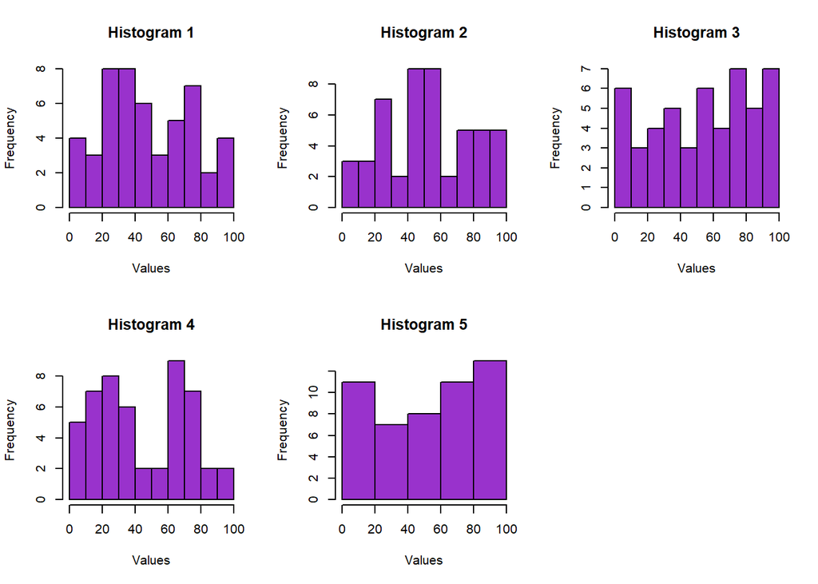

```r
par(mfrow = c(2, 3))
for (i in 1:5) {
  hist(samples[,i],
       xlab = "Values",
       main = paste("Histogram", i),
       col = "darkorchid")
}

par(mfrow = c(2, 3)) # Reset window
```

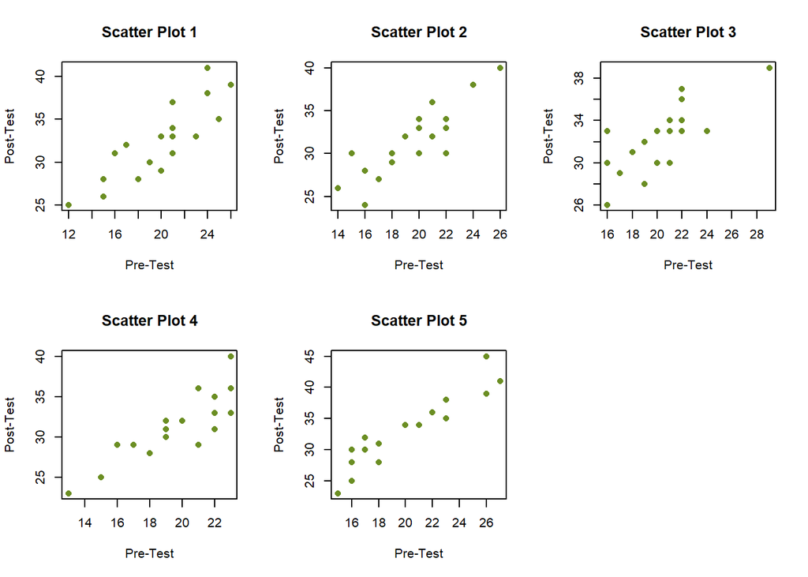

```r
for (i in 1:5) {
plot(scores$pre[(i + 20*(i - 1)):(i + 20*(i - 1) + 19)],
     scores$post[(i + 20*(i - 1)):(i + 20*(i - 1) + 19)],
     xlab = "Pre-Test",
     ylab = "Post-Test",
     main = paste("Scatter Plot", i),
     pch = 16,
     col = "olivedrab")
}
```